# 编程语言：应用与解释 Programming Languages: Application and Interpretation

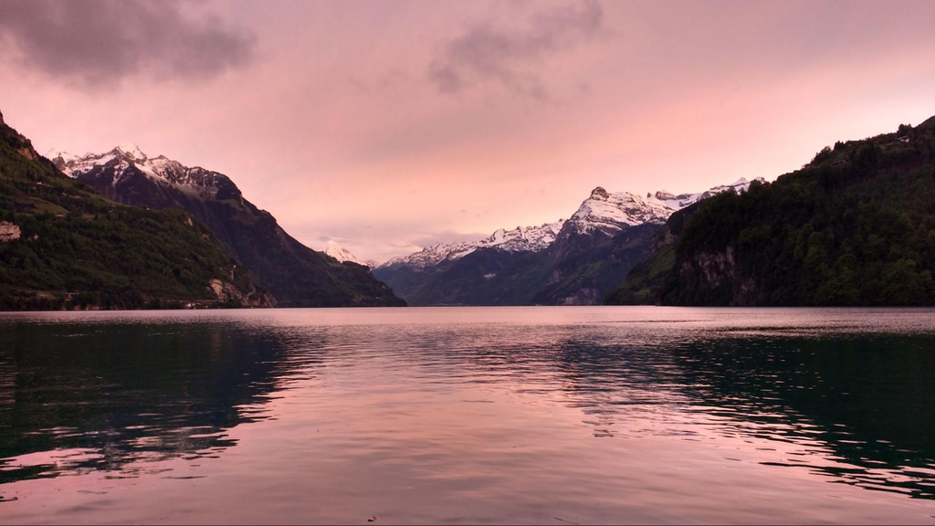

Shriram Krishnamurthi，布朗大学 Shriram Krishnamurthi  
Brown University

版本 3.2.5，2025-07-14，© Shriram Krishnamurthi，CC-BY-NC-SA 4.0。 Version 3.2. 5 , 2025-07-14 , © Shriram Krishnamurthi, [CC-BY-NC-SA 4.0](http://creativecommons.org/licenses/by-nc-sa/4.0/) .

如果你制作衍生版本，请遵守许可协议的规定。 If you make a derivative version, please follow the license rules.

本书免费提供。如发现任何违规行为，请予以举报。 This book is provided free of cost . Please report any violations.

有关本书的最新信息，请访问 plai.org。 For up-to-date information about this book, please visit [plai.org](https://www.plai.org/) .

关于如何报告错误的信息，也请到该网站查阅。 Please also go there for information on how to report errors.

# 前言 Preface

## 为什么学习编程语言？ Why Study Programming Languages?

开始学习一门课程时，先问问为什么要学，总是有益的。那么，让我们列出几个理由，说明这门课为何值得学习： It is always healthy to begin a course of study by asking why we should engage in it. So let us list a few reasons to justify this one:

- 编程语言是人类发明的最美妙、最强大的事物之一。 Programming languages are some of the most beautiful and powerful objects invented by human beings.
- 它们让我们——确切地说，迫使我们——精确地表达思想，作为回报，我们得以指挥能力强大的机器执行我们的意愿。 They let us—indeed, force us to—capture our thoughts precisely, and in return command machines of immense power to do our bidding.
- 对程序员来说，它们是终极的人机界面。 To a programmer, they are the ultimate human-computer interface.
- 它们在产业界十分重要：重要到大公司会创造新语言，或将现有语言纳入自己的阵营，以建立或扩大市场份额。 They are industrially important: so important that major companies create new languages or co-opt existing ones to establish or expand their market share.
- 它们体现了一种新的知识形式：《计算机程序的构造和解释》将其称为“过程性认识论”。 They embody a new form of knowledge: what [Structure and Interpretation of Computer Programs](https://mitp-content-server.mit.edu/books/content/sectbyfn/books_pres_0/6515/sicp.zip/index.html) called a “procedural epistemology”.
- 它们让我们能够证明关于表达手段和表达极限的强有力论断。还有多少种其他语言能让我们做到其中任何一点呢？ They enable us to prove powerful statements about the means and limits of our expression. How many other languages let us do either?

还需要多少理由呢？ How many more reasons does one need?

## 目标读者 The Target Audience

从第一版开始，本书的目标读者就是“另外的 90%”。也就是说，我猜想，编程语言课上大约有 10% 的学生与教师一样：他们对这门学科满怀热情，有强烈的学习动力，在个人层面认同它，并且可能希望继续深入研究。他们是出色的学生，其中许多人将成为下一代教师。有几本很棒的书正是为这种学生设计的——或者至少最适合他们。 Starting with the first edition, this book’s target has been “the other 90%”. That is, I conjecture that roughly 10% of students in a programming languages class are like the educator: they are deeply excited about and motivated to learn the subject, identify with it personally, and may want to continue to study it further. These are wonderful students, and many of them will go on to become the next generation of educators. There are several terrific books that are designed—or at least, work best—for this kind of student.

但大多数学生——比如说 90%——可能没有这种深切的个人认同。相反，他们希望把这门学科学到足以成为更好的计算机科学家。他们需要学什么，又需要怎样学习呢？他们就是本书的目标读者。一方面，本书努力与许多编程任务建立联系。与此同时，一味迎合这样的读者又太容易了。本书试图在这些联系与对基本原理的关注之间取得平衡，让学习者在很长时间内都能从这些原理中受益。 But most of them—say 90%—may not have this deep personal identification. Instead, they want to learn the subject enough to become better computer scientists. What do they need to learn, and how do they need to learn it? They are the target audience for this book. On the one hand, the book tries to connect to many programming tasks. At the same time, it’s too easy to pander to such an audience. The book tries to balance these connections with a focus on principles that will stand the learner in good stead for a long time.

当然，我相信那 10% 的学生也会从本书中学到有用的东西。至少，他们或许能学到看待这门学科的另一种视角，也可能对与自己不同的学习者多一些共情。再不济，使用过本书早期版本的学生中，有远不止十几位顺利获得了编程语言方向的博士学位，其中几位如今也已成为教授。所以，至少本书没有害了他们。这样的胜算，我可以接受。 Of course, I believe the 10% will learn something useful from this book, too. If nothing else, they may learn a different perspective on the subject, and maybe also develop some empathy for learners not like themselves. If nothing else, well over a dozen students who used earlier editions of this book successfully completed PhDs in programming languages, and several are themselves professors now. So, at least, the book has not harmed them. I can live with those odds.

我写这本书时也考虑了在职程序员。他们中许多人可能未受过正规的计算机科学教育，或者至少没在所受教育中得到对编程语言的恰当介绍。在某个时候，他们中的一些人会像那 90% 的学生一样，对自己使用的媒介产生好奇。我希望本书能与他们对话，温和地引导他们离开日常编程的喧嚣，进入一个反省与思考的空间。 I have also written this book with working programmers in mind. Many of them may have not had a formal computer science education, or at least one that included a proper introduction to programming languages. At some point, like that 90% of students, some of them become curious about the media they use. I want this book to speak to them, gently drawing them away from the hustle and bustle of daily programming into a space of reflection and thought.

## 为什么要有第三版 Why a Third Edition

过去几年里，我的研究有很大一部分是在考察学生如何在许多不同层面理解编程语言。我的发现使我确信，我们需要一种新的方法来教授这些内容。这一版就是朝着这个目标迈出的第一轮尝试。（这也是用我如今的“口吻”重写文字的机会；二十多年来，我的口吻已发生了很大变化。这一版与第一版几乎没有相同的文字，与第二版也只有部分相同。） Over the past several years, a significant part of [my research](https://cs.brown.edu/~sk/Publications/Papers/Published/) examines how students understand programming languages at many different levels. What I have learned has convinced me that we need a new approach to teaching this material. This edition is a first iteration to that end. (It was also a chance to rewrite the prose in my current “voice”, which has evolved a lot over two decades. Virtually no text is in common with the first edition, and only some with the second.)

我们所处的世界，其语言的多样性与新颖性也前所未有。似乎每隔几周，我就会听说有人在尝试某种新的语言实验。健壮而有趣的运行时系统随处可得——从 Erlang 的运行时、Java 虚拟机，到浏览器中的 JavaScript、Racket 的运行时，等等，种类繁多——让人们很容易得到一个“配套齐全”的可运行原型，把精力集中在创新上。这既影响着尝试学习新语言的人，也影响着尝试构建语言的人。 We also live in a world of unprecedented linguistic diversity and novelty. It seems like every few weeks I learn about someone trying some new linguistic experiment. The wide availability of robust and interesting run-time systems—as diverse as Erlang’s, the Java Virtual Machine, the browser’s JavaScript, Racket’s, and more—makes it easy to get a working prototype “with batteries” and focus on novelty. This affects both people trying to learn new languages and those trying to build them.

与此相关的是，第一版对编程语言采取了非常“古典”的视角，这受到我自身在该学科所受正规训练的影响。第二版开始脱离这种视角，但尚未完全摆脱。第三版则基本挣脱了这些束缚，更多地反映了当今的语言格局。能讲解“脚本编程”和“渐进类型”等主题而不把它们简化为口号和空话的书并不多；本书尝试用更严谨的方式来讲解它们。 Relatedly, the first edition took a very “classical” look at programming languages, shaped by my own formal training in the subject. The second edition started to migrate from it, but not entirely. The third edition has mostly broken free of those constraints, reflecting more of the current linguistic landscape. There are not many books that cover topics like “scripting” and “gradual typing” without reducing them to slogans and fluff; this book tries to cover them in more rigorous ways.

但这种多样性也提出了一个重要挑战：该如何认识它？在其他学科中，我们通过把新事物分解成已熟悉的组成元素来认识它们。共同之处提供了一个锚点，也是理解其新颖之处的出发点。对于编程语言，这些元素是什么呢？教学传统认为，“范式”是这样一种组织手段，但在我看来，它是某个时代留下的垂死遗产：那时，计算领域希望被视为一门“科学”，并觉得实现这一点的最佳方式，就是把事物放进贴着标签的盒子里。但编程语言是人造的实体，而非自然的实体，没有什么能阻止设计者自由混合不同盒子里的东西——事实上许多人已经这么做了。当几乎一切都是“多范式”的时候，我们该如何理解这个世界呢？ But all this diversity brings up the important challenge of how to approach it. In other disciplines, we approach new objects by decomposing them into familiar constituent elements. Their commonalities provide an anchor, and a point of departure for what makes them novel. What are those elements for programming languages? Pedagogic tradition holds that “paradigms” are one such organizational medium, but I find them a moribund legacy of a period when computing wanted to be viewed as a “science” and felt the best way to do this was to put things in labeled boxes. But programming languages are artificial, not natural, entities, and nothing prevents designers from freely mixing between the boxes—as indeed many have. When virtually everything is “multiparadigm”, how can we make sense out of the world?

## 组织我们的学习 Structuring Our Study

正如我在别处更详尽地论述过的，把编程语言看作特性的集合更有意义。特性就是构件。当然，一旦组合起来，语言更像化合物而非混合物：各个特性会以不易预测的方式相互作用。因此，理解各个特性及其组合，是认识一种语言的有用方法。 As I have argued in greater length [elsewhere](https://cs.brown.edu/~sk/Publications/Papers/Published/sk-teach-pl-post-linnaean/) , it is more meaningful to think of programming languages as aggregates of features . The features are the building blocks. Of course, once combined, languages are more like compounds than like mixtures: the features interact in ways that may not be easy to predict. Understanding both the features and their compositions is then a valuable way to approach a language.

本书围绕一个核心思想展开：SMoL，即语言的标准模型（Standard Model of Languages）。它体现了许多广泛使用的编程语言的计算核心，从 C# 和 Java，到 JavaScript、Lua、Python 和 Ruby，再到 OCaml 和 Racket。敏锐的读者会发现，这种共性完全不理会“范式”的界线。相反，所有这些语言（以及许多其他语言）在很大程度上拥有共同的计算核心：安全的运行时系统、自动内存管理、急切求值、一等的词法作用域函数、一阶的可修改变量，以及一等的可修改结构。现代编程要求我们深入理解这些内容。例如，我认为，如果不理解 SMoL，你就无法理解带修改的并发、静态成员或所有权。 The book revolves around a central idea, SMoL , the Standard Model of Languages. This is the embodiment of the computational core of many of our widely-used programming languages, from C# and Java to JavaScript, Lua, Python, and Ruby to OCaml and Racket. The astute reader will notice that this commonality pays no respect to “paradigms”. Rather, all these languages (and many others), to a large extent, have a common computational core: safe runtime systems, automated memory management, eager evaluation, first-class lexically-scoped functions, first-order mutable variables, and first-class mutable structures. Contemporary programming demands a deep understanding of these. For instance, I believe you cannot make sense of concurrency with mutation, static members, or ownership, without understanding SMoL.

然而，由于语言是人造的，而编程又是一种几乎可以无限塑造的材料，即使是“标准”特性，在历史上也出现过变体。因此，在逐个学习特性的同时，我们也要研究每个特性内部的变化。为此，我们采用神秘语言方法：使用固定的语法，探索同一特性可能表现出的不同方式。我们希望借助对比案例的认知理论来改善学习效果。 However, because languages are artificial and programming is an almost infinitely malleable material, even “standard” features have historically seen variation. Therefore, while we progress across features, we also want to study variation within them. We do this by using the [mystery language](https://cs.brown.edu/~sk/Publications/Papers/Published/pkf-teach-pl-exp-adv-think/) approach: with a fixed syntax, we explore the different ways the same feature can behave. This hopes to build on the cognitive theory of [contrasting cases](https://www.cultofpedagogy.com/contrasting-cases/) to improve learning .

当然，哪些内容属于 SMoL，需要作出判断：当某个特性没有广泛存在于大量不同语言中（例如静态类型），或者在不同语言之间差异过大（例如对象）时，我就认为它不再属于标准模型。但这不是价值判断：本书会较深入地探索 SMoL，然后把注意力转向几个“非标准”特性，它们不仅重要，而且优美迷人。 What goes in SMoL is, of course, a judgment call: when a feature isn’t present across a large number of diverse languages (like static types), or shows too much variation between languages (like objects), I argue that it’s no longer part of the standard model. But it is not a value judgment: in this book we explore SMoL in some depth, then turn our attention to several non-“standard” features that are not only important but also beautiful and fascinating.

谈到实现，本书提供了另一个支柱：SImPl，即标准实现方案（Standard Implementation Plan）。其思想是，从抽象语法树的角度思考编程语言很有用；这种树适合用代数数据类型表示；而处理这种树的程序则是一个递归函数，其形式主要由类型的结构引导。这一层次的描述涵盖了两种标准的求值媒介：解释器和编译器。它也概括了类型检查器、类型推断、静态分析等的本质。因此，学生应当熟练掌握这种结构，以便在想要实现自己的语言实验时使用。 Turning to implementation, the book provides another pillar: SImPl , the Standard Implementation Plan. This is the idea that programming languages are usefully thought of in terms of an abstract syntax tree; this tree is represented well by an algebraic datatype; and a program that processes this tree is a recursive function that is largely guided by the structure of the type. This level of description encompasses both of the standard media for evaluation: interpreters and compilers. It also captures the essence of type-checkers, type inference, static analysis, and more. Thus, students should gain facility with this structure for when they want to implement their own language experiments.

## 学习装备 Equipment for Learning

虽然随着时间推移，所有材料可能都会纳入本书，但目前，本书属于一个更广泛的学习生态系统，即布朗大学的 CSCI 1730 课程。所有材料都可在以下网站获得（请找最新年份）： While over time all the material might be incorporated into this book, for now, the book is part of a broader learning ecosystem, which is the course CSCI 1730 at Brown University. All the materials are available from the following site (look for the latest year):

[https://cs.brown.edu/courses/csci1730/](https://cs.brown.edu/courses/csci1730/2022/)

课程作业分成几条“线索”： The course’s work is divided into several “threads”:

- SMoL 使用自动化辅导程序教学生学习 SMoL。 SMoL uses an automated [tutor](https://smol-tutor.xyz/tutor/) to teach students SMoL.
- ML 让学生逐一探究神秘语言。 ML makes students work through mystery languages .
- Stacker 让学生借助一种新工具 Stacker 来思考程序求值，它提供了一台概念机器。读者会发现，在 Stacker 中运行 SMoL 程序并研究其行为极为有用。 Stacker makes students reflect on program evaluation using a novel tool, the [Stacker](https://smol-tutor.xyz/stacker/) , which provides a notional machine. Readers will find it extremely useful to run SMoL programs in the Stacker and study how they behave.
- “实现”线索让学生构建可运行的实现。 The Implementation thread has student build working implementations.
- “分析”线索要求学生将课堂所学与现实世界的语言情境联系起来。我尤其鼓励教师在自己的课堂中使用“分析”线索的作业。 The Analysis thread asks students to relate material they are learning in the class to real-world language contexts. I especially encourage educators to make use of the Analysis thread assignments in their classes.

本书大量使用 Racket。不过，这种说法太简单了。Racket 的力量来自它定义新语言的能力：这篇文章和这段短视频对此有更详细的讨论。确实，本书中有些程序用 Racket 编程语言（#lang racket）编写，但许多程序用一种专为本书理想化设计的语言（#lang plait）编写。此外，还有些部分定义了自己的语言：其中有多种 SMoL 语言，还有远不止十几种神秘语言。因此，虽然学习者必须对括号语法多一点耐心，但作为回报，他们将获得丰厚的学习体验。 This book makes heavy use of [Racket](https://racket-lang.org/) . However, that is too simplistic. Racket’s power comes from its ability to define new languages: [this article](https://cs.brown.edu/~sk/Publications/Papers/Published/fffkbmt-programmable-prog-lang/) and [this brief video](https://youtu.be/R_1TnfCuxK8) discuss that in more detail. Indeed, some programs in this book are written in the Racket programming language ( #lang racket ), but many are in a language ideally designed for this book ( #lang plait ). In addition, other parts define their own languages: there are multiple SMoL languages and well over a dozen mystery languages. Thus, while the learner must demonstrate some forbearance for parenthetical syntax, in return they will be richly rewarded with learning experiences.

从某种意义上说，#lang 的存在推动了本书的重新设计。我曾参与这个特性的设计，这让我格外不自在：面向广泛读者的材料，不应围绕与自己感情过深的工作展开。这也是为什么第一版使用了 Racket 的前身，而第二版没有使用。然而，在这个过程中，我意识到自己剥夺了学生大量的学习机会：毕竟，还有什么能比一种专为设计语言而设计的语言，更适合用来研究语言呢？例如，神秘语言的最初版本既零散又令人困惑；把它们重新实现为一组 Racket #lang 语言之后，它们变得简单清晰得多（也能让它们自身成为直接研究的对象）。因此，这一版加倍（甚至不止加倍）使用 Racket。要把它用好可能有些棘手（例如，要避免模式混淆），也许需要几轮尝试，但这番努力非常值得。 The existence of #lang , in some ways, drove this book’s redesign. I had some hand in that feature’s [design](https://cs.brown.edu/~sk/Publications/Papers/Published/cffk-macros-to-dsls/) , which made me acutely self-conscious: materials intended to be for a broad audience shouldn’t be about work too close to my heart. That was one of the reasons that, while the first edition used a predecessor of Racket, the second edition did not. In the process, however, I realized that I was depriving my students of numerous learning opportunities: after all, what better medium for the study of languages than a language designed for designing languages? For instance, the first version of the mystery languages were ad hoc and confusing; reimplementing them as a collection of Racket #lang s made them far simpler and clearer (and also open them up to be an object of direct study themselves). Thus, this edition doubles down (and then some) on the use of Racket. Getting it right can be tricky (e.g., avoiding mode confusion) and may take a few iterations, but it’s well worth the effort.

# 致谢 Acknowledgments

## 读者 Readers

对于这一版，我感谢以下指出错误并提出改进建议的学生及其他读者： For this edition, I thank the students and other readers who have pointed out errors and suggested improvements:

Alex Ding, Alhassan Choubassi, Aman Nougrahiya, Ashley Chung, Calder Ruhl Hansen, Charles Gagnon, Christina Peng, David Beazley, David Fryd, David Young, Dries Vanspauwen, garare992 @ GitHub, Geoffrey J. Teale, Jack Zeng, Jason Eveleth, Kevin Gibbons, Kristoffer Balintona, Liam Bai, Matisse Doucet, Michael Fishman, Nicholas Vadasz, Nolan Serbent, Paul Biberstein, Paul Carduner, Peter Li, rainforest-of-code @ GitHub, Robert Wang, Sara Jensen, Shihang Li, Sidharth Anand, Sreshtaa Rajesh, Suzanne Rivoire, Tomas Dougan, Tomasz Mizera, Venkat, Will Crichton, Wout Bergmans, Zack Amiton, Zack Eisbach, Zhao Min

其中几位提出了许多建议，或者提出的建议特别出色： A few have made numerous and/or especially good suggestions:

Benjamin Lee, Cedric Sirianni, Ian Arawjo, Jamie Cooper, Neil Ramaswamy, Qiuhong Wei, Tianren Dong, Tom Van Cutsem, Tony Garnock-Jones, Yongming Han, Zack Cheng

最后，还有几位因为对细节的关注和持之以恒的精神，值得格外赞扬： Finally, a few deserve extra special praise for their attention to detail and staying power:

Chen Li, David Bremner, Ezra Marks, Futao Wei

## 其他所有人 Everyone Else

这一版建立在前两版的基础上。我始终深深感谢所有帮助那些版本问世的人。 This edition builds on [two](https://cs.brown.edu/~sk/Publications/Books/ProgLangs/2007-04-26/) [previous editions](https://cs.brown.edu/~sk/Publications/Books/ProgLangs/2007-04-26/) . I remain deeply grateful to all the people who helped make those editions happen.

我研究组的博士生，尤其是 Jack Wrenn，多年来一直容忍我抱怨自己的课程。他们一边翻白眼，一边听我说完，挡掉最糟糕的主意，并充实那些较好的想法。能与他们共事，我深感幸运。 My group’s PhD students, especially Jack Wrenn, have tolerated years of my complaining about my course. Amidst their eye-rolling they heard me out, batted away my worst ideas, and fleshed out my better ones. I am deeply fortunate to be able to work with them.

John Clements 在布朗大学的学术休假，极大地推动了我重新思考基础内容，而我们的交谈也提醒我，我有多么怀念与他相伴的时光。 John Clements’s sabbatical at Brown was a huge fillip to my rethinking the basics, and our conversations reminded me how much I have missed his company.

Kuang-Chen Lu 从一开始就相信这个项目，并构建和维护了使其成为可能的许多东西。他还领导了支撑本书的研究，他的博士论文使我（以及许多其他人）的教学方式得到显著改进。 Kuang-Chen Lu believed in this project from the start, and built and maintained a good deal that makes it possible. He has also led the research that powers this book, and his dissertation has led to significant improvements in how I (and many others) teach.

Matthew Flatt 的印记遍布本书。我尤其感谢他带来的 Racket 生态系统和 #lang 概念，后者推动了本书的重新设计；还要特别感谢他的 plait 语言，本书的大量代码都以它为核心。 Matthew Flatt’s fingerprints are all over this book. I especially thank him for the Racket ecosystem and the #lang concept, which drove the redesign of this book, and for the plait language especially, which is central to much of this book’s code.

本书的大部分思想和文字，都是在 East Bay Bike Path 上形成的。衷心感谢修建并维护这条自行车道的人们，愿风总在你们背后助力（如果你在下午 2 点到 4 点之间先向南骑，再向北返回，往往确实能一路顺风）。 Most of this book’s ideas and composition were formed on the East Bay Bike Path. To the people who made it happen and keep it alive, many thanks, and may the winds always be at your back (which they often can be, if you ride south and then back north between 2pm and 4pm).

最后，如果没有 Kathi 和 Tara 的爱与支持，本书就不会从脑海走到纸面。她们同样容忍了我多年对课程的抱怨，也一边翻白眼，一边给予支持。她们是我的磐石。 Finally, this book wouldn’t have migrated from head to page without the love and support of Kathi and Tara, who also tolerated years of my complaining about my course and provided their own eye-rolling support. They are my rocks.

# ••••• 学习 SMoL ••••• ••••• Learning SMoL •••••

我们先来学习语言的标准模型，它是随后大部分学习内容的基础。 We begin by learning the Standard Model of Languages, which undergirds most of our subsequent study.

# 自学 SMoL Teach Yourself SMoL

本书的核心是你对 SMoL 的理解。不过，为避免阅读变成一种被动体验，Kuang-Chen Lu 实现了一系列可按自身进度学习的辅导程序，教你学习 SMoL。这些辅导程序既传授概念知识，也教授重要术语。 This work is centered around your understanding of SMoL. However, to avoid a passive reading experience, [Kuang-Chen Lu](https://lukuangchen.github.io/) has implemented a series of self-paced tutors to teach you SMoL. The tutors both give you conceptual knowledge and teach you important terminology.

重要的是，它们还有简短快捷的测试题，确保你走在正确的道路上。这些问题有两个目的。首先，它们迫使你认真学习辅导内容：你不能只是被动地滚动页面。其次，它们针对的是学习这些材料时已知的常见误解。其他学习者犯过这些错误，所以你也可能犯。要留心！ Importantly, they also have short, quick test questions to make sure you’re on the right track. These questions serve two ends. First, they force you to pay attention to the tutor: you can’t just scroll through passively. Second, they are based on known misconceptions with this material. Other learners made these mistakes, so you might too. Pay attention!

由于这些教程目前不支持中途停止、保存进度后再继续，我们把材料拆成了一组小型（！）辅导程序，每个涵盖一个概念（有时甚至不到一个）。这样，你可以完成一两个或三个辅导程序，休息一下，稍后再接着学。 Because the tutorials currently do not support stopping, saving your work, and resuming, we have broken the material down into a set of small (!) tutors, each covering one concept (and sometimes even less). That way, you can do a tutor or three, take a break, and pick up later.

所有辅导程序都可以在这里找到： The tutors are all available from here:

https://smol-tutor.xyz/tutor/

在继续阅读本书之前，你应该先完成这些辅导程序！ Before you go on in this book, you should do the tutors!

关于 SMoL，一个重要的认识是：它的语义嵌入了我们几乎所有关于编程的思考。最明显的是，我们的算法分析基础——想想空间和时间的大 O 记号——有一个底层的、往往隐含的成本模型。例如，这个成本模型假设，参数在函数调用发生时求值，传递大型数据时不会复制这些数据。这也正是 SMoL 规定应该发生的行为。 The important thing to understand about SMoL is that its semantics is embedded into almost all our thinking about programming. Most notably, our algorithm analysis foundations—think Big-O for space and time—have an underlying, often implicit, cost model. That cost model assumes, for instance, that arguments are evaluated when a function call occurs, and that passing large data does not copy them. This is exactly what SMoL says should happen, too.

# ••••• 求值 ••••• ••••• Evaluation •••••

我们先来研究构建求值器的过程：求值器就是把程序变成答案的程序。我们将遵循 SImPl，同时探索 SMoL 中的核心概念。 We begin by studying the process of building evaluators: programs that turn programs into answers. We will follow SImPl, while exploring the core concepts in SMoL.

# 纸上求值 Evaluation on Paper

## 求值器 Evaluators

我们想要实现一种编程语言：也就是说，编写一个求值器（即某种“将程序归约为值”的东西）。在开始处理计算机带来的复杂性之前，先在纸上理解求值的工作方式会有所帮助。 We’re trying to implement a programming language: that is, to write an evaluator (i.e., something that “reduces programs to values”). It helps if we can first understand how evaluation works on paper, before we start dealing with computer complexities.

深入细节之前，值得知道的是，大体上有两类求值器（还有它们的许多组合）。它们采取截然不同的策略： Before we get into the details, it’s worth knowing that there are broadly speaking two kinds of evaluators (as well as many combinations of them). They follow very different strategies:

- 解释器接收一个程序并模拟其执行。也就是说，解释器所做的，正是我们期望“运行程序”时应该做的事。 An interpreter consumes a program and simulates its execution . That is, the interpreter does what we would expect “running the program” should do.
- 编译器接收一个程序并生成另一个程序。这个输出程序随后还必须进一步求值。 A compiler consumes a program and produces another program . That output program must then be further evaluated.

也就是说，解释器将某种语言 L 中的程序映射为值： That is, an interpreter maps programs in some language L to values:

interpreter :: Program L → Value

目前，我们暂不严格规定值究竟是什么，只把它非正式地理解为用户想看到的答案——换句话说，某种不能或不需要继续求“值”的东西。相比之下， We leave open exactly what a value is for now, informally understanding it to be an answer the user would want to see—put differently, something that either cannot or does not need to be further e-valu-ated. In contrast,

compiler :: Program L → Program T

也就是说，从 L 到 T 的编译器（我们用 T 表示“目标”）接收 L 中的程序，生成 T 中的程序。我们并没有规定这个 T 程序必须如何求值。它可以直接解释执行，也可以继续编译。例如，可以把 Scheme 程序编译成 C。这个 C 程序可以直接解释执行，但也很可能会被编译成汇编。然而，我们不能无穷无尽地编译下去：在最底层，必须存在某种解释器（例如，在计算机硬件中）来提供答案。 That is, a compiler from L to T (we use T for “target”) consumes programs in L and produces programs in T . We aren’t saying about how this T program must be evaluated. It may be interpreted directly, or it may be further compiled. For instance, one can compile a Scheme program to C. The C program may be interpreted directly, but it may very well be compiled to assembly. However, we can’t keep compiling ad infinitum: at the bottom, there must be some kind of interpreter (e.g., in the computer’s hardware) to provide answers.

注意，解释器和编译器本身也是用某种语言编写的程序，它们自身也必须运行。自然，这会引出一些有趣的想法和问题。 Note that interpreters and compilers are themselves programs written in some language and must themselves run. Naturally, this can lead to interesting ideas and problems.

在学习中，我们将主要关注解释器，但也会看到一种非常轻量的编译器。解释器很有用，因为： In our study, we will focus primarily on interpreters, but also see a very lightweight form of compilers. Interpreters are useful because:

1. 编写一个简单的解释器通常比编写编译器容易得多。 A simple interpreter is often much easier to write than a compiler.
2. 调试解释器有时比调试编译器容易得多。 Debugging an interpreter can sometimes be much easier than debugging a compiler.

因此，它们提供了一种人人都能采用的、有用的“基线”实现技术。而编译器通常值得用一整门课程来学习。 Therefore, they provide a useful “baseline” implementation technology that everyone can reach for. Compilers can often take an entire course of study.

## 术语 Terminology

在网上，经常看到人们说“解释型语言”和“编译型语言”。这些术语毫无意义。这不只是一个评价；而是字面上的陈述：它们在逻辑上说不通。解释和编译是人们用来对程序求值的技术。一种语言（几乎）从来不会规定应当如何对它求值。因此，每个实现者都可以自由选择自己想要的策略。 It is common, on the Web, to read people speak of “interpreted languages” and “compiled languages”. These terms are nonsense . That isn’t just a judgment; that’s a literal statement: they do not make sense. Interpretation and compilation are techniques one uses to evaluate programs. A language (almost) never specifies how it should be evaluated. As a result, each implementer is free to choose whatever strategy they want.

举个例子，C 经常被选为典型的“编译型语言”，而 Scheme 则经常被当作“解释型语言”介绍。然而，C 的解释器确实存在过（虽说数量不多）；事实上，我最初学习 C 时就用过一个。同样，Scheme 的编译器有很多；我最初学习 Scheme 时就用过一个。Python 也有若干解释器和编译器。 Just as an example, C is often chosen as a canonically “compiled language”, while Scheme is often presented as an “interpreted language”. However, there have been (a handful of) interpreters for C; indeed, I used one when I first learned C. Likewise, there are numerous compilers for Scheme; I used one when I first learned Scheme. Python has several interpreters and compilers.

此外，这种看似明确的区分，在实践中经常被打破。如今，许多语言都有“JIT”，也就是即时编译。也就是说，求值器起初作为解释器工作。如果发现自己反复解释同一段代码，它就把这段代码编译，并改用编译后的代码。何时以及如何这样做，是一个复杂而迷人的主题，但它清楚地表明，两者之间没有泾渭分明的界线。 Furthermore, this seemingly hard distinction is frequently broken down in practice. Many languages now have a “JIT”, which stands for just-in-time compilation. That is, the evaluator starts out as an interpreter. If it finds itself interpreting the same code over and over, it compiles it and uses the compiled code instead. When and how to do this is a complex and fascinating topic, but it makes clear that the distinction is not a bright line.

有些人会被实现所呈现的界面迷惑。许多语言提供读入—求值—打印循环（REPL），也就是交互式界面。解释器往往更容易做到这一点。不过，许多具有这种界面的系统，会在提示符处接收代码，将其编译、运行，再向用户呈现答案；它们把所有这些步骤都隐藏起来了。因此，界面不能表明你所见的是哪一种实现。把一种实现称为“交互式”或“非交互式”，或许有意义，但这并不反映底层语言的性质。 Some people are confused by the interface that an implementation presents. Many languages provide a read-eval-print loop (REPL), i.e., an interactive interface. It is often easier for an interpreter to do this. However, many systems with such an interface accept code at a prompt, compile it, run it, and present the answer back to the user; they mask all these steps. Therefore, the interface is not an indicator of what kind of implementation you are seeing. It is perhaps meaningful to refer to an implementation as “interactive” or “non-interactive”, but that is not a reflection of the underlying language.

简而言之，请记住： In short, please remember:

- （大多数）语言并不规定实现方式。使用哪种实现，由不同平台以及其他考量决定。 (Most) Languages do not dictate implementations. Different platforms and other considerations dictate what implementation to use.
- 实现通常采用两种主要策略之一——解释和编译——但许多实现也是两者的混合。 Implementations usually use one of two major strategies—interpretation and compilation—but many are also hybrids of these.
- 某个具体实现可能提供交互式或非交互式界面。然而，这并不会自动揭示其底层的实现策略。 A specific implementation may offer an interactive or non-interactive interface. However, this does not automatically reveal the underlying implementation strategy.
- 因此，“解释型语言”和“编译型语言”这两个术语毫无意义。 Therefore, the terms “interpreted language” and “compiled language” are nonsensical.

## 手动模拟解释器 Simulating an Interpreter by Hand

既然已经决定编写解释器，那在研究如何让它做到我们想做的事情之前，先来理解我们究竟想让它做什么。 Since we have decided to write an interpreter, let’s start by understanding what we are trying to get it to do, before we start to investigate how we will make it do it.

考虑下面这个程序： Let’s consider the following program:

(define (f x) (+ x 1))

(f 2)

它会得到什么结果？我们都能猜到，它得到 3。现在假设有人问，为什么它得到 3？你会怎么回答？ What does it produce? We can all guess that it produces 3 . Now suppose we’re asked, why does it produce 3 ? What might you say?

你很可能会说，因为 f 的函数体中的 x 被替换成了 2，然后我们计算函数体，这就是答案： There’s a good chance you’ll say that it’s because x gets replaced with 2 in the body of f, then we compute the body, and that’s the answer:

→ (f 2)

→ (+ x 1)，其中 x 被替换为 2 → (+ x 1) where x is replaced by 2

→ (+ 2 1)

→ 3

现在来看这个程序的扩展版本： Now let’s look at an extended version of the program:

;; f is the same as before

(define (g z)

(f (+ z 4)))

(g 5)

我们可以采用相同的过程： We can use the same process:

→ (g 5)

→ ( f (+ z 4))，其中 z 被替换为 5 → ( f (+ z 4)) where z is replaced by 5

→ (f (+ 5 4))

→ (f 9)

→ (+ x 1)，其中 x 被替换为 9 → (+ x 1) where x is replaced by 9

→ (+ 9 1)

→ 10

术语：我们将函数头中的变量称为形式参数，将函数调用中的表达式称为实际参数。因此，在 f 中，x 是形式参数，而 9 是实际参数。有些人还会用 argument 代替 parameter，但这两个术语之间并没有真正的区别。 Terminology: We call the variables in the function header the formal parameters and the expressions in the function call the actual parameters . So in f , x is the formal parameter, while 9 is an actual parameter. Some people also use argument in place of parameter , but there’s no real difference between these terms.

注意，我们曾有一个选择：既可以这样做， Observe that we had a choice: we could have gone either

→ (f (+ 5 4))

→ (f 9)

也可以这样做， or

→ (f (+ 5 4))

→ (+ x 1)，其中 x 被替换为 (+ 5 4) → (+ x 1) where x is replaced by (+ 5 4)

目前，两种方式会得到相同的答案，但这实际上是个影响深远的决定！事实上，它是编程语言设计中最深刻的选择之一。 For now, both will produce the same answer , but this is actually a very consequential decision! It is in fact one of the most profound choices in programming language design.

术语：前一种选择称为急切求值：可以把它想成，在开始函数调用之前，“急切地”将实际参数归约成一个值。后一种选择称为惰性求值：可以把它想成，不急于执行求值。 Terminology: The former choice is called eager evaluation: think of it as “eagerly” reducing the actual parameter to a value before starting the function call. The latter choice is called lazy evaluation: think of it as not rushing to perform the evaluation.

SMoL 采用急切求值。这有充分的理由，我们稍后会探讨 [ 👉 ]。 SMoL is eager . There are good reasons for this, which we will explore later [ 👉 ].

好了，回到求值。让我们再前进一步： Okay, so back to evaluation. Let’s do one more step:

;; f is the same as before

;; g is the same as before

(define (h z w)

(+ (g z) (g w)))

(h 6 7)

我们可以再次查看这些步骤： Once again, we can look at the steps:

→ (h 6 7)

→ (+ (g z) (g w))，其中 z 被替换为 6，w 被替换为 7 → (+ (g z) (g w)) where z is replaced by 6 and w is replaced by 7

→ (+ (g 6) (g 7))

→ (+ (f (+ 6 4)) (g 7))

→ (+ (f 10) (g 7))

→ (+ (+ x 1) (g 7))，其中 x 被替换为 10 → (+ (+ x 1) (g 7)) where x is replaced by 10

→ (+ (+ 10 1) (g 7))

→ (+ 11 (g 7))

→ (+ 11 (f (+ 7 4)))

→ (+ 11 (f 11))

→ (+ 11 (+ x 1))，其中 x 被替换为 11 → (+ 11 (+ x 1)) where x is replaced by 11

→ (+ 11 (+ 11 1))

→ (+ 11 12)

→ 23

注意，我们又有了一些选择： Observe that we again had some choices:

- 是一次替换两个调用，还是一次处理一个？ Do we replace both calls at once, or do one at a time?
- 如果是后者，先处理左边还是右边？ If the latter, do we do the left or the right one first?

语言也必须对这些问题作出决定！上面，我们再次采用了 SMoL 的做法：完成一个调用后才开始另一个，因此 SMoL 是顺序的。如果我们同时替换两个调用，探索的就是一种并行语言。按照惯例，大多数语言选择从左到右的顺序，因此我们在 SMoL 中也这样选择。 Languages have to make decisions about these, too! Above, we’ve again done what SMoL does: it finishes one call before starting the other, which makes SMoL sequential . Had we replaced both calls at once, we’d be exploring a parallel language. Conventionally, most languages choose a left-to-right order, so that’s what we choose in SMoL.

## 替换 Substitution

顺便说一句，注意到没有，回答这些问题并不需要懂计算机编程。你在初高中代数课上就做过类似的事。你学到的说法可能是“代入”，而不是“替换”。我们这里遵循的正是同一个过程。事实上，我们可以把编程看作代数的自然延伸，只不过数据类型有趣得多：不只有数字，还有字符串、图像、列表、表格、向量场、视频，等等。 By the way, observe that you didn’t need to know any computer programming to answer these questions. You did something similar in middle- and high-school algebra classes. You probably learned the phrase substitution for “replaced with”. That’s the same process we’re following here. And indeed, we can think of programming as a natural outgrowth of algebra, except with much more interesting datatypes: not only numbers but also strings, images, lists, tables, vector fields, videos, and more.

好了，这就给了我们一种实现求值器的方法： Okay, so this gives us a way to implement an evaluator:

- 找到一种表示程序源代码的方式（例如，字符串或树）。 Find a way to represent program source (e.g., a string or a tree).
- 寻找下一个要求值的表达式。 Look for the next expression to evaluate.
- 通过（文本）替换得到一个新程序。 Perform substitution (textually) to obtain a new program.
- 继续求值，直到只剩一个值。 Continue evaluating until there’s nothing left but a value.

然而，正如你可能已经猜到的，大多数编程语言实际并不是这样工作的：一般来说，这会慢得令人难以忍受。所以，我们必须找到更好的方法！ However, as you might have guessed, that’s not how most programming languages actually work: in general it would be painfully slow. So we’ll have to find a better way!

# 表示算术 Representing Arithmetic

让我们开始考虑真正编写一个求值器。我们将从一种简单的算术语言入手，再逐步扩展。因此，我们的语言会有 Let’s start thinking about actually writing an evaluator. We’ll start with a simple arithmetic language, and then build our way up from there. So our language will have

- 数字 numbers
- 一些算术运算：实际上，只有加法 some arithmetic operations: in fact, just addition

暂时没有其他内容，以便专注于基础。我们会逐渐扩充它。 and nothing more for now, so we can focus on the basics. Over time we’ll build this up.

不过，在考虑求值器的函数体之前，我们需要弄清楚它的类型：尤其是，它接收什么？ Before we can think about the body of an evaluator, however, we need to figure out its type: in particular, what will it consume?

## 表示程序 Representing Programs

那么，求值器接收什么呢？它接收程序。因此，我们需要弄清楚如何表示程序。 Well, what does an evaluator consume? It consumes programs . So we need to figure out how to represent programs .

当然，计算机一直都在表示程序。编写代码时，文本编辑器保存着程序源代码。磁盘和内存中的每个可执行文件，都是程序的一种表示。我们访问网页时，网页会向我们发送一个 JavaScript 程序。这些全都是计算机中表示的程序。但就我们的需求而言，这些表示都有些不便，我们马上就会想出一种更好的表示。 Of course, computers represent programs all the time. When we’re writing code, our text editor holds the program source. Every executable on disk and in memory is a representation of a program. When we visit a Web page, it sends down a JavaScript program. These are all programs represented in the computer. But all these are a bit inconvenient for our needs, and we’ll come up with a better representation in a moment.

在思考表示方式之前，先想想要表示什么。以下是一些（算术）程序的例子： Before thinking about represent ations , let’s think about what we’re represent ing . Here are some example (arithmetic) programs:

1

0

-1

2.3

1 + 2

3 + 4

问题已经出现了。程序该怎么写呢？你能看出这个问题的走向：1 与 2 的和应该写成 Already we have a question. How should we write our program? You can see where this is going: should we be writing the sum of 1 and 2 as

1 + 2

还是写成 or as

(+ 1 2)

+ 1 2

1 2 +

等等。（甚至还可以问，基本数字该用哪种记数系统：例如，应该写 3 还是 III？如果你真的愿意，用后者也能编程。） and so on. (For that matter, we can even ask what numeral system to use for basic numbers: e..g, should we write 3 or III ? You can [program with the latter](https://github.com/shriram/roman-numerals) if you’d really like to.)

因此，这些都是很有价值的人因考量。但就理解语言的底层模型而言，它们眼下会分散注意力。所以，我们需要一种表示所有这些不同程序的方法，使其忽略这些区别。 Thus, these are great human-factors considerations. But for now these are a distraction in terms of getting to understand the models underlying languages. Therefore, we need a way to represent all these different programs in a way that ignores these distinctions.

## 抽象语法 Abstract Syntax

这就引出了 SImPl（标准实现方案）的第一部分：创建所谓的抽象语法。在抽象语法中，我们表示输入的本质，忽略表面的语法细节。因此，在抽象语法中，上面的所有程序都会有完全相同的表示。 This leads us to the first part of SImPl (the Standard Implementation Plan): the creation of what is called abstract syntax . In abstract syntax, we represent the essence of the input, ignoring the superficial syntactic details. Thus, in abstract syntax, all of the above programs will have the exact same representation.

抽象语法是程序在计算机内部的一种表示。可以用许多种数据作为表示，所以让我们想想，可能想要表示什么样的程序。为简单起见，假设我们的语言只有数字和加法；一旦能够处理它们，再处理更多运算就容易了。以下是一些（表层语法）程序示例： An abstract syntax is an in-computer representation of programs. There are many kinds of data we can use as a representation, so let’s think about the kinds of programs we might want to represent. For simplicity, we’ll assume that our language has only numbers and addition; once we can handle that, it’ll be easy to handle additional operations. Here are some sample (surface syntax) programs:

1

2.3

1 + 2

1 + 2 + 3

1 + 2 + 3 + 4

当然，在传统算术记法中，必须考虑运算顺序，以及哪些运算优先于哪些运算。在抽象语法中，这又是一个我们想忽略的细节；我们转而假定，内部使用的表示相当于加上全部括号的表达式，这些问题都已解决。因此，上面最后两个表达式就好像被写成了 In conventional arithmetic notation, of course, we have to worry about the order of operations and what operations take precedence over what others. In abstract syntax, that’s another detail we want to ignore; we’ll instead assume that we are working internally with the equivalent of fully-parenthesized expressions, where all these issues have been resolved. Thus, it’s as if the last two expressions above were written as

(1 + 2) + 3 或 1 + (2 + 3) (1 + 2) + 3 or 1 + (2 + 3)

1 + ((2 + 3) + 4)

那么请注意，加法运算的每一边，本身都可以是一个完整的表达式。这强烈地提示了内部应采用哪种表示：树。事实上，抽象语法树的使用如此普遍，以至于它的缩写 AST 经常不加解释就直接使用；在有关这个主题的书籍、论文、博客文章等资料中，你都会看到它。 Observe, then, that each side of the addition operation can be a full-blown expression in its own right. This gives us a strong hint as to what kind of representation to use internally: a tree . Indeed, it’s so common to use abstract syntax trees that the abbreviation, AST, is routinely used without explanation; you can expect to see it in books, papers, blog posts, etc. on this topic.

你很可能以前见过这个想法：它叫作句子图解（可在维基百科了解更多）。例如，下面是句子“He studies linguistics at the university”（他在大学学习语言学）的图解： You have quite possibly seen this idea before: it’s called sentence diagramming (read more on [Wikipedia](https://en.wikipedia.org/wiki/Sentence_diagram) ). Here, for instance, is a diagram of the sentence “He studies linguistics at the university”:

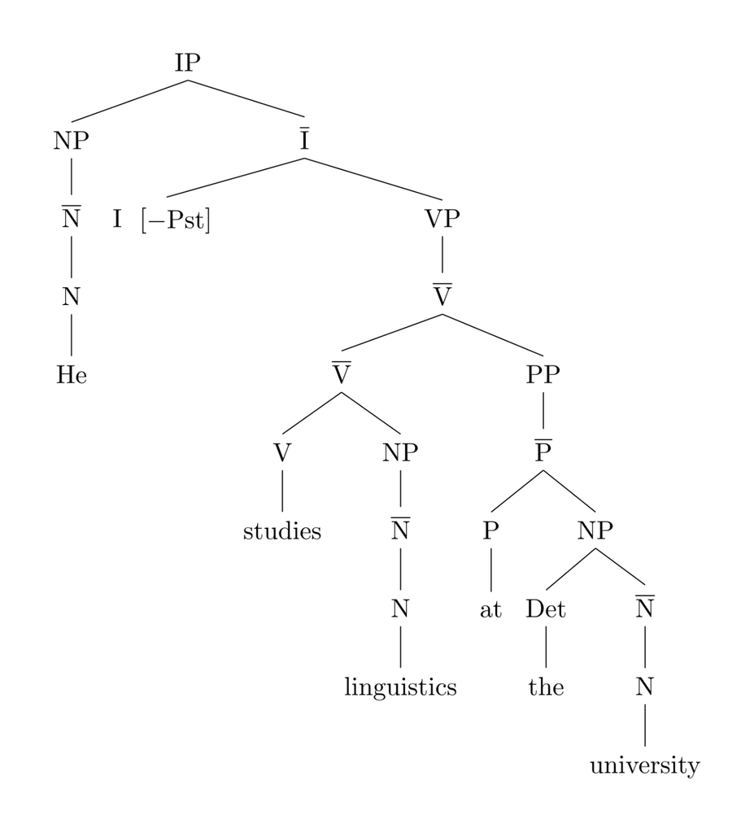

作者：Xbarst1.jpg：Russky1802；衍生作品：Maxdamantus。此文件衍生自 Xbarst1.jpg，公有领域，https://commons.wikimedia.org/w/index.php?curid=21979041 By Xbarst1.jpg: Russky1802 derivative work: Maxdamantus - This file was derived from: Xbarst1.jpg:, Public Domain, https://commons.wikimedia.org/w/index.php?curid=21979041

NP 是名词短语，V 是动词，依此类推。请看，句子图解如何把一个线性的句子转变成语法结构的树形表示。我们想对程序做同样的事。 An NP is a Noun Phrase, V is a Verb, and so on. Observe how the sentence diagram takes a linear sentence and turns it into a tree-shaped representation of the grammatical structure. We want to do the same for programs.

## 表示抽象语法 Representing Abstract Syntax

在本书的其余部分，除非另有说明，我们都会用 Racket 的 plait 语言来实现各种东西。请确保已安装 plait，以便跟着操作。 In the rest of this book, except where indicated otherwise, we will implement things in the [plait](https://docs.racket-lang.org/plait/index.html) language of Racket. Please make sure you have plait installed to follow along.

我们将在 plait 中创建一个新的树数据类型来表示 AST。在上面的句子图解中，树叶是单词，节点是语法术语。在我们的 AST 中，树叶将是数字，而节点则是对表示各子表达式的树进行的运算。目前只有一种运算：加法。下面是在 plait 语法中的表示方法： We will create a new tree datatype in plait to represent ASTs. In the sentence diagram above, the leaves of the tree are words, and the nodes are grammatical terms. In our AST, the leaves will be numbers, while the nodes will be operations on the trees representing each sub-expression. For now, we have only one operation: addition. Here’s how we can represent this in plait syntax:

(define-type Exp

[num (n : Number)]

[plus (left : Exp) (right : Exp)])

它的意思是： This says:

- 我们正在定义一个新类型 Exp We are defining a new type, Exp
- 有两种构造 Exp 的方式 There are two ways of making an Exp
- 一种方式是通过构造器 num： One way is through the constructor num :
- num 接收一个参数 A num takes one argument
- 这个参数必须是一个真正的数字 That argument must be an actual number
- 另一种方式是通过构造器 plus： The other way is through the constructor plus :
- plus 接收两个参数 A plus takes two arguments
- 两个参数都必须是 Exp Both arguments must be Exp s

如果对理解后文有帮助，可以把它看作与下面的 Java 伪代码骨架非常相似（用 Python 的 dataclass 也有类似写法）： If it helps as you read what follows, this is very analogous to the following Java pseudocode skeleton (or the analog with Python dataclasses):

abstract class Exp {}

class num extends Exp {

num(Number n) { … }

}

class plus extends Exp {

plus(Exp left, Exp right) { … }

}

来看看前面的一些例子会如何表示： Let’s look at how some of the previous examples would be represented:

| 表层语法 Surface Syntax | AST |
| --- | --- |
| 1 | (num 1) |
| 2.3 | (num 2.3) |
| 1 + 2 | (plus (num 1) (num 2)) |
| (1 + 2) + 3 | (plus (plus (num 1) (num 2)) (num 3)) |
| 1 + (2 + 3) | (plus (num 1) (plus (num 2) (num 3))) |
| 1 + ((2 + 3) + 4) | (plus (num 1) (plus (plus (num 2) (num 3)) (num 4))) |

注意这些例子中的几点： Observe a few things about these examples:

- 这个数据类型定义不允许我们直接表示 1 + 2 + 3 + 4 这样的表层语法项；在构造相应 AST 项的时候，所有歧义都必须已经得到处理。 The datatype definition does not let us directly represent surface syntax terms such as 1 + 2 + 3 + 4 ; any ambiguity has to be handled by the time we construct the corresponding AST term.
- 数字的表示可能看起来有点奇怪：我们有一个 num 构造器，它唯一的工作就是“包裹”一个数字。这样做是为了让表示保持一致。等到开始编写处理这些数据的程序时，就会明白为什么这样做。 The number representation might look a bit odd: we have a num constructor whose only job is to “wrap” a number. We do this for consistency of representation. As we start writing programs to process these data, it’ll become clear why we did this.
- 注意，表达式中每个重要部分都进入了它的 AST 表示，尽管方式未必相同。尤其是，加法中的 + 由构造器表示；它不是参数的一部分。 Notice that every significant part of the expression went into its AST representation, though not always in the same way. In particular, the + of an addition is represented by the constructor ; it is not part of the parameters.
- AST 完全不在乎使用了什么表层语法。最后一项也可以写成 (+ 1 (+ (+ 2 3) 4))，甚至写成图中的形式，想必都会产生相同的 AST。 The AST really doesn’t care what surface syntax was used. The last term could instead have been written as  
  (+ 1  
  (+ (+ 2 3)  
  4))  
  or even as

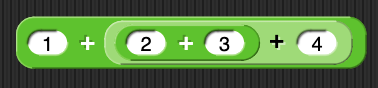

  and it would presumably produce the same AST.

简言之，AST 是在程序中表示程序的树形数据。这是一个深刻的思想！事实上，它是 20 世纪的伟大思想之一，建立在 Gödel（编码）、Turing（通用机）、von Neumann（存储程序计算机）和 McCarthy（元循环解释器）的杰出工作之上。 In short, ASTs are tree-structured data that represent programs in programs . This is a profound idea! In fact, it’s one of the great ideas of the 20th century, building on the brilliant work of Gödel (encoding), Turing (universal machine), von Neumann (stored program computer), and McCarthy (metacircular interpreter).

旁注：源程序并非每个部分都在 AST 中有所表示。例如，1 + 2 和 1 + 2 想必会用相同方式表示，忽略其中的空格。实际上，真正的语言实现确实需要了解某些语法信息：例如，像 DrRacket 那样，在出错时高亮显示程序源代码的相应部分。因此，现实中的实现使用抽象语法，但还附带元数据，将其关联回源代码。 Aside: Not every part of the source program has been represented in the AST. For instance, presumably both 1 + 2 and 1 + 2 would be represented the same way, ignoring the spaces. In practice, a real language implementation does need to know something about the syntax: for instance, to highlight pieces of the program source when there is an error, as DrRacket does. Therefore, real-world implementations use abstract syntax but with metadata relating it back to the source.

# 算术求值 Evaluating Arithmetic

## 定义求值器 Defining the Evaluator

看过如何表示算术程序之后，我们转向编写一个求值器程序，把它们变成答案。 Having seen how to represent arithmetic programs, we turn to writing an evaluator program that turns them into answers.

这个求值器的类型是什么？显然，它接收程序，这里程序用 Exp 表示。它生成什么？在当前情况下，所有这些表达式都会生成数字。因此，我们暂时把它叫作计算器，简称 calc。于是，可以给 calc 赋予如下类型 What is the type of this evaluator? Clearly it consumes programs, which here are represented by Exp s. What does it produce? In this case, all these expressions are going to produce numbers. For this reason, we’ll call this a calculator, or calc for short, for now. We can thus give calc the type

(calc : (Exp -> Number))

现在尝试定义它的函数体。显然，我们必须有 Let’s now try to define its body. Clearly we must have

(define (calc e)

…)

在函数体中，给定一个 Exp，我们要用 type-case 将它拆开。type-case 告诉我们有两种可能，每种都带有一些额外数据（这在实质上等同于我们在 Java 中会采用的方法分派）： In the body, given an Exp , we will want to take it apart using type-case , which tells us there are two options, each with some additional data (this is the moral equivalent of the method dispatch we’d have used in Java):

(type-case Exp e

[(num n) …]

[(plus l r) …])

如果整个表达式已经是一个数字，会怎样呢？既然已经有了答案，直接返回即可。否则，就必须将两边相加： What happens in the case that the whole expression is already a number? Well, we have our answer, so we just return it. Otherwise, we have to add the two sides:

(type-case Exp e

[(num n) n]

[(plus l r) (+ l r)])

这样，整个函数体就是： giving us an overall body of:

(define (calc e)

(type-case Exp e

[(num n) n]

[(plus l r) (+ l r)]))

让我们运行它……哎呀！出现类型错误了！它告诉我们，加法期待一个数字，但 l 不是数字：它是一个 Exp。啊，这是因为 l 和 r 仍然表示表达式，而不是表达式求值所得的答案。要解决这个问题，我们需要某种能把表达式变成数字的东西……这恰恰就是我们正在定义的东西！因此，我们改为这样写 Let’s run it to…oops! We get a type error! It tells us that addition is expecting a number, but l is not a number: it’s an Exp . Ah, that’s because l and r still represent expressions , not the answer that the expressions evaluate to. To fix that, we need something that can turn an expression into a number…which is precisely what we’re defining! Thus, we instead write

(define (calc e)

(type-case Exp e

[(num n) n]

[(plus l r) (+ (calc l) (calc r))]))

现在类型检查器满意了。果然，可以确认这些例子得到了预期结果。例如： The type-checker is happy now. And sure enough, we can confirm that our examples produce what we expect. For instance:

(calc (num 1))

得到 1， produces 1 ,

(calc (plus (num 1) (num 2)))

得到 3，而 produces 3 , and

(plus (num 1)

(plus (num 2) (num 3)))

得到 6。 produces 6 .

旁注：我们略过了一个细节：我们假定 + 总是表示数字加法（在 AST 中将它命名为“plus”，就已隐含了这一点）。但有些语言允许“相加”的类型有很多种：例如，它也可以连接字符串。在这样的语言中，AST 中的名称可能会更通用，求值器也需要处理各种可能的行为。 Aside: We’ve glossed over a detail: we’ve assumed that + always means numeric addition (which was already implicit in calling it “ plus ” in the AST). But some languages allow any number of different types to be “added”: e.g., it can also concatenate strings. In such languages, the name in the AST might be something more generic, and the evaluator would need to handle the different possible behaviors.

事实上，我们还略过了更基本的事情：数字加法是什么意思，甚至数字本身究竟是什么。正如在“神秘语言：算术”中所见，这里有许多选择。在我们的计算器中，采用的是 plait 的数字（在 num 中）和 plait 的加法（通过使用 +）。calc 中的这些位置也告诉我们，要改变这些选择，应当到哪里修改。 In fact, we’ve glossed over something even more basic: what numeric addition means, or for that matter, even what numbers are. As we see from the Mystery Language: Arithmetic, there are many choices here. In our calculator, we have adopted numbers from plait (in num ) and addition from plait (by using + ). Those places in calc also tell us where we would go to change those choices.

## 测试求值器 Testing the Evaluator

上面的例子不错，但应该用测试的语法将它们写出来，让计算机自动替我们检查： The examples above are fine, but we should write these in the syntax of tests , so that the computer checks them for us automatically:

(test (calc (num 1)) 1)

(test (calc (num 2.3)) 2.3)

(test (calc (plus (num 1) (num 2))) 3)

(test (calc (plus (plus (num 1) (num 2))

(num 3)))

6)

(test (calc (plus (num 1)

(plus (num 2) (num 3))))

6)

(test (calc (plus (num 1)

(plus (plus (num 2)

(num 3))

(num 4))))

10)

果然，运行后，Racket 确认所有这些测试都通过了。 Sure enough, when we run this, Racket confirms that all these tests pass.

专业小窍门：逐一查看所有测试输出，判断是否有测试失败，会令人厌烦。只要在测试之前加上 Pro Tip: It can get annoying to scan through all this testing output to see whether any of the tests failed. Simply add

(print-only-errors #true)

Racket 就会不再报告通过的测试，让你专注于失败的测试：换句话说，没有消息就是好消息。 before your tests and Racket will suppress reporting on the passing tests, so you can focus on the ones that failed: in other words, no news is good news.

一般来说，测试要早、要勤、要全面。编程语言求值器把我们的思想转换成计算机的行动。因此，它们能精确完成这件事至关重要。这就是为什么语言实现是你能想到的测试最充分的软件之一（上一次因为语言实现中的错误而受阻是什么时候？），而且，那些几乎能容忍其他任何软件中的错误的人，对于语言实现中的错误却远没有那么宽容。 In general, test early, often, and extensively. Programming language evaluators translate our thoughts into computer actions. Therefore, it’s critical that they do so precisely. This is why language implementations are some of the most tested software you can imagine (when’s the last time you were stopped by a bug in your language implementation?), and people who will tolerate bugs in just about any other software are much less forgiving of bugs in implementations.

## 一些更微妙的测试 Some Subtler Tests

试试下面的测试： Try the following test:

(test (calc (plus (num 0.1) (num 0.2))) 0.3)

不出所料，它失败了：但错误消息显示，左边求值为 0.30000000000000004。这应该提醒我们，实际得到的是浮点加法。这是因为 plait 会把像 0.1 这样带小数点的数字视为浮点位串。然而，浮点位串无法精确表示数字 0.3。事实上，plait 的 test 允许少许数值误差，所以上面通过的那个测试能够成立。（这是因为，在 plait 中，0.3 确实精确地表示数字 0.3，因为它是直接写出的字面量，而不是浮点计算的结果。） As expected, it fails: but the error message reveals that the left-hand side evaluated to 0.30000000000000004. This should be a cue that we have actually gotten [floating point](https://0.30000000000000004.com/) addition. This is because plait treats numbers written with a decimal point, like 0.1 , as floating point bitstrings. However, floating point bitstrings cannot precisely represent the number 0.3. In fact, plait’s test allows a little bit of numeric slack so that the passing test above works. (This is because in plait, 0.3 really does precisely represent the number 0.3, because it was written literally and not the result of a floating-point computation.)

这强化了前面顺带提过、因而容易被忽略的一点：采用 plait 的原语，也就继承了它的语义。这可能是我们想要的，也可能不是！因此，用宿主语言编写求值器时，必须确保它的语义就是我们想要的，否则可能会遇到令人不快的意外。如果想要不同的行为，就必须明确地实现它。 This reinforces a point we made in passing above and was therefore easy to miss: by adopting plait’s primitives, we have also inherited its semantics. This may or may not be what we wanted! Therefore, when writing an evaluator using a host language, we have to make sure that its semantics are the one we want, otherwise we could be in for an unpleasant surprise. If we want different behavior, we have to implement it explicitly.

## 结语 Conclusion

至此，我们对 SImPl 的初次考察就结束了：我们在程序中表示了一个程序，又在程序中处理了这个被表示的程序。我们刚刚编写了第一个处理程序的程序——现在可以大展身手了！ This concludes our first look at SImPl: we have represented a program in a program, and we have processed that represented program in a program. We have just written our first program that processes programs—now we’re off to the races!

# 解析：从源代码到 AST Parsing: From Source to ASTs

## 问题 The Problem

前面我们走过了 SImPl 的基本步骤，但留下了一个大问题：如何把程序转换成 AST 表示？当然，最简单的方法就是已经做过的：直接写 AST 构造器，例如， Earlier we went through the basic steps of the SImPl, but we left open a big question: how do we get programs into the AST representation? Of course, the simplest way is what we already did: to write the AST constructors directly, e.g.,

(num 1)

(plus (num 1) (num 2))

(plus (num 1)

(plus (num 2) (num 3)))

正如前面指出的，这种方式的优点是还能忽略程序源代码究竟如何书写。 which, as we noted, has the virtue of also ignoring exactly how the program source was written.

然而，这可能非常繁琐。例如，我们不希望每次想写一个数字时，都得写 (num …)！尤其是，越繁琐，我们就越不可能编写数量多或复杂的测试，这就特别令人遗憾。因此，我们希望有一种更方便的表层语法，以及一个将它翻译成 AST 的程序。 However, this can get very tedious. We don’t want to have to write (num …) every time we want to write a number, for instance! In particular, the more tedious it is the less likely we are to write many or complex tests, and that would be especially unfortunate. Therefore, we’d like a more convenient surface syntax, along with a program to translate that into ASTs.

正如已经看到的，我们可以使用大量不同的表层语法，甚至不局限于文本语法：它可以是图形的、口语的、手势的（想象你置身于虚拟现实环境中），等等。正如前面指出的，这种广泛的交互方式很重要——尤其当程序员有身体方面的限制时——但它不在当前研究范围内。即使采用文本语法，也必须处理歧义等问题（例如算术的运算顺序）。 As we have already seen, there is a large number of surface syntaxes we can use, and we aren’t even limited to textual syntax: it could be graphical; spoken; gestural (imagine you’re in a virtual reality environment); and so on. As we have noted, this wide range of modalities is important—especially so if the programmer has physical constraints—but it’s outside the range of our current study. Even with textual syntax, we have to deal with issues like ambiguity (e.g., order of operations in arithmetic).

一般来说，将输入语法转换成 AST 的过程称为解析。仅仅解析这个主题，就足以写一整本小册子……所以我们不这么做。相反，我们选择一种在便利和简单之间取得合理平衡的语法，即 Racket 的括号语法，plait 对它有专门支持。也就是说，我们会把上面的例子写成 In general, the process of converting the input syntax into ASTs is called parsing . We could write a whole booklet just on parsing…so we won’t. Instead, we’re going to pick one syntax that strikes a reasonable balance between convenience and simplicity, which is the parenthetical syntax of Racket, and has special support in plait. That is, we will write the above examples as

1

(+ 1 2)

(+ 1 (+ 2 3))

并看看 Racket 如何帮助我们方便地处理它们。事实上，本书将遵循一个约定（Racket 并不在乎这个约定，因为它对 ()、[] 和 {} 一视同仁）：我们用 {} 而不是 () 来书写要表示的程序。因此，上面的三个程序变成 and see how Racket can help us make these convenient to work with. In fact, in this book we will follow a convention (that Racket doesn’t care about, because it treats () , [] , and {} interchangeably): we’ll write programs to be represented using {} instead of () . Thus, the above three programs become

1

{+ 1 2}

{+ 1 {+ 2 3}}

## S 表达式 S-Expressions

这种语法有个名称：S 表达式（s- 的来历是历史原因）。在 plait 中，书写这些表达式时，我们会在前面加一个反引号（`）。反引号后面跟一个 Racket 项，其类型就是 S-Exp。以下是一些 S 表达式的例子： There is a name for this syntax: these are called s-expressions (the s- is for historical reasons). In plait, we will write these expressions preceded by a back-tick ( ` ). A back-tick followed by a Racket term is of type S-Exp . Here are examples of s-expressions:

`1

`2.3

`-40

这些都是数字 S 表达式。我们还可以写 These are all numeric s-expressions. We can also write

`{+ 1 2}

`{+ 1 {+ 2 3}}

这并不明显，但它们实际上是列表 S 表达式。可以这样询问来判断 It’s not obvious, but these are actually list s-expressions. We can tell by asking

> (s-exp-list? `1)

- Boolean

#f

> (s-exp-list? `{+ 1 2})

- Boolean

#t

> (s-exp-list? `{+ 1 {+ 2 3}})

- Boolean

#t

所以第一个不是，但后两个是；类似地， So the first is not but the second two are; similarly,

> (s-exp-number? `1)

- Boolean

#t

> (s-exp-number? `{+ 1 {+ 2 3}})

- Boolean

#f

S-Exp 类型是包裹实际数字或列表的容器，我们可以把它们提取出来： The S-Exp type is a container around the actual number or list, which we can extract:

> (s-exp->number `1)

- Number

1

> (s-exp->list `{+ 1 2})

- (Listof S-Exp)

(list `+ `1 `2)

现在动手！如果将 s-exp->number 应用于列表 S 表达式，或将 s-exp->list 应用于数字 S 表达式，会发生什么？如果把其中任一个应用于根本不是 S 表达式的东西呢？现在就试试看！得到的结果是否略有不同？ Do Now: What happens if you apply s-exp->number to a list s-exp or s-exp->list to a number s-expression? Or either to something that isn't an s-expression at all? Try it right now and find out! Do you get somewhat different results?

更仔细地看一下上面的最后一个输出。所得列表有三个元素，其中两个是数字，而第三个是别的东西： Let’s look at that last output above a bit more closely. The resulting list has three elements, two of which are numbers, but the third is something else:

`+

它是一个符号 S 表达式。符号类似字符串，但在操作和性能上有些不同。字符串有许多操作（例如取子串），而符号被作为原子对待；除转换为字符串外，它们唯一支持的其他操作就是相等性判断。作为回报，符号的相等性可以在常数时间内检查。 is a symbol s-expression. Symbols are like strings but somewhat different in operations and performance. Whereas there are numerous string operations (like substrings), symbols are treated atomically; other than being converted to strings, the only other operation they support is equality. But in return, symbols can be checked for equality in constant time.

符号与 Racket 变量具有相同的语法，因此特别适合表示类似变量的东西。于是 Symbols have the same syntax as Racket variables, and hence are perfect for representing variable-like things. Thus

> (s-exp-symbol? `+)

- Boolean

#t

> (s-exp->symbol `+)

- Symbol

'+

这个输出展示了 Racket 中符号的写法：使用单引号（'）。 This output shows how symbols are written in Racket: with a single-quote ( ' ).

还有其他种类的 S 表达式，但目前这些就够了！有了这些，我们就能编写第一个解析器了！ There are other kinds of s-expressions as well, but this is all we need for now! With this, we can write our first parser!

## 解析器中的第一位 Primus Inter Parsers

现在动手！想想我们希望解析器具有什么类型。 Do Now: Think about what type we want for our parser.

解析器需要生成什么？计算器所接收的东西，也就是 Exp。它接收什么？以“方便”的语法书写的程序源表达式，也就是 S-Exp。因此，它的类型必须是 What does our parser need to produce? Whatever the calculator consumes, i.e., Exp . What does it consume? Program source expressions written in a “convenient” syntax, i.e., S-Exp . Hence, its type must be

(parse : (S-Exp -> Exp))

也就是说，它把对人（比较）友好的语法转换为计算机的内部表示。 That is, it converts the human-friendly(ier) syntax into the computer’s internal representation.

编写它需要一定程度的细致较真。首先，需要一个条件判断，检查给定的是哪种 S 表达式： Writing this requires a certain degree of pedantry. First, we need a conditional to check what kind of s-exp we were given:

(define (parse s)

(cond

[(s-exp-number? s) …]

[(s-exp-list? s) …]))

如果是数字 S 表达式，就要提取其中的数字，再传给 num 构造器： If it’s a numeric s-exp, then we need to extract the number and pass it to the num constructor:

(num (s-exp->number s))

否则，就要提取列表，检查列表的第一个元素是不是加法符号。如果不是，就发出错误信号： Otherwise, we need to extract the list and check whether the first thing in the list is an addition symbol. If it is not, we signal an error:

(let ([l (s-exp->list s)])

(if (symbol=? '+

(s-exp->symbol (first l)))

…

(error 'parse "list not an addition")))

否则，通过递归处理两个子部分，创建一个 plus 项。 Otherwise, we create a plus term by recurring on the two sub-pieces.

(plus (parse (second l))

(parse (third l)))

把这些合在一起： Putting it all together:

(define (parse s)

(cond

[(s-exp-number? s)

(num (s-exp->number s))]

[(s-exp-list? s)

(let ([l (s-exp->list s)])

(if (symbol=? '+

(s-exp->symbol (first l)))

(plus (parse (second l))

(parse (third l)))

(error 'parse "list not an addition")))]))

这确实有点繁琐，不过幸运的是，本书中解析的难度差不多也就到此为止了！从现在起，你看到的基本都会是同一种模式，可以随意照着写。 It’s all a bit much, but fortunately this is about as hard as parsing will get in this book! Everything you see from now on will basically be this same sort of pattern, which you can freely copy.

当然，我们应当确保为解析器编写了良好的测试。例如： We should, of course, make sure we’ve got good tests for our parser. For instance:

(test (parse `1) (num 1))

(test (parse `2.3) (num 2.3))

(test (parse `{+ 1 2}) (plus (num 1) (num 2)))

(test (parse `{+ 1

{+ {+ 2 3}

4}})

(plus (num 1)

(plus (plus (num 2)

(num 3))

(num 4))))

现在动手！还有哪些种类的测试是我们应该编写的？ Do Now: Are there other kinds of tests we should have written?

我们只编写了正向测试。对于预期会出错的情况，也可以编写负向测试： We have only written positive tests. We can also write negative tests for situations where we expect errors:

(test/exn (parse `{1 + 2}) "")

test/exn 接收一个字符串，它必须是错误消息的子串。上面的测试使用空字符串，而不是诸如 "addition" 这样的字符串，你可能会感到意外。试运行这个例子，探究原因。可以如何改进解析器来解决这个问题？ test/exn takes a string that must be a substring of the error message. You might be surprised that the test above uses the empty string rather than, say, "addition" . Try out this example to investigate why. How can you improve your parser to address this?

还应检查的情况包括子部分太少或太多。例如，加法被定义为恰好接收两个子表达式。如果源程序中一个都没有，或者有一个、三个、四个……呢？解析所要求的，就是这种细致较真。 Other situations we should check for include there being too few or too many sub-parts. Addition, for instance, is defined to take exactly two sub-expressions. What if a source program contains none, one, three, four, …? This is the kind of pedantry that parsing calls for.

考虑完这些情况，我们就处在一个很理想的位置了，因为 parse 生成的输出可以被 calc 接收。因此，我们可以组合这两个函数！更好的是，可以编写一个辅助函数替我们完成组合： Once we have considered these situations, we’re in a happy place, because parse produces output that calc can consume. We can therefore compose the two functions! Better still, we can write a helper function that does it for us:

(run : (S-Exp -> Number))

(define (run s)

(calc (parse s)))

现在，我们可以用方便得多的方式重写原来的求值器测试： So we can now rewrite our old evaluator tests in a much more convenient way:

(test (run `1) 1)

(test (run `2.3) 2.3)

(test (run `{+ 1 2}) 3)

(test (run `{+ {+ 1 2} 3})

6)

(test (run `{+ 1 {+ 2 3}})

6)

(test (run `{+ 1 {+ {+ 2 3} 4}})

10)

把它与先前的 calc 测试比较一下！ Compare this against the calc tests we had earlier!

# 条件式求值 Evaluating Conditionals

到目前为止，我们的语言只有算术。在“神秘语言：条件式”的基础上，现在来研究如何扩展语言，使其也支持条件式。实际语言中的条件表达式可能相当复杂，但就我们的目标而言，拥有三个部分的 if 就足够了：条件、then 分支和 else 分支。稍后，学会如何扩展语言之后，就能看到如何在此之上叠加更复杂的条件表达式。 So far our language has had only arithmetic. Building on Mystery Language: Conditionals, we will now examine how to extend our language to also support conditionals. There can be quite complex conditional expressions in real languages, but for our purposes it will suffice to have an if with three parts: the conditional, the then-branch, and the else-branch. Later, when we learn how to extend the language, we can see how to layer more sophisticated conditional expressions atop this.

按照 SImPl，我们至少必须做两件事： In SImPl, we have to do at least two things:

1. 扩展表示表达式的数据类型，使其包括条件式。 Extend the datatype representing expressions to include conditionals.
2. 扩展求值器，使其能够处理这些新表达式（的表示）。 Extend the evaluator to handle (the representation of) these new expressions.

可选地，如果有解析器，我们还应当 Optionally, if we have a parser, we should also

3. 扩展解析器，使其能够生成这些新表示。 Extend the parser to produce these new representations.

## 扩展 AST Extending the AST

由于已经规定条件式有三个部分，我们只需在 AST 中表示这三个部分。这很直接： Because we have fixed our conditionals to have three parts, we just need to represent that in the AST. This is straightforward:

(define-type Exp

[num (n : Number)]

[plus (left : Exp) (right : Exp)]

[cnd (test : Exp) (then : Exp) (else : Exp)])

真正的工作将发生在求值器中。 The real work will happen in the evaluator.

## 扩展计算器 Extending the Calculator

显然，加入条件式并不改变计算器先前的行为，所以可以保留原有部分，只关注 if 的处理： Clearly, adding conditionals doesn’t change what our calculator previously did, we can leave that intact, and just focus on the handling of if :

(define (calc e)

(type-case Exp e

[(num n) n]

[(plus l r) (+ (calc l) (calc r))]

[(cnd c t e) …]))

事实上，我们可以递归地求值每一项，以备有用： Indeed, we can recursively evaluate each term, in case it’s useful:

(define (calc e)

(type-case Exp e

[(num n) n]

[(plus l r) (+ (calc l) (calc r))]

[(cnd c t e) … (calc c) … (calc t) … (calc e) …]))

让我们逐一来看。 Let’s take these one at a time.

但现在遇到了一个问题。调用 (calc c) 的结果是什么？我们预期它是某种布尔值。但语言中还没有布尔值！ But now we run into a problem. What is the result of calling (calc c) ? We expect it to be some kind of Boolean value. But we don’t have Boolean values in the language!

问题还不止如此。上面，我们同时写了 (calc t) 和 (calc e)。然而，条件式的要点恰恰是，我们不想对两者都求值，而只对其中一个求值。因此，必须根据某种标准选择求值哪一个。 That’s not all. Above, we have written both (calc t) and (calc e) . However, the whole point of a conditional is that we don’t want to evaluate both, only one. So we have to pick which one to evaluate based on some criterion.

## 条件式的设计空间 The Design Space of Conditionals

即便最简单的条件式，也会让我们接触到语言设计中的许多变化。其意图是先对 test-expression 求值；如果结果为真，就（只）对 then-expression 求值，否则就（只）对 else-expression 求值。（通常把这两部分称为分支，因为程序的控制流必须选择其中一个。）然而，即便这样一个简单构造，也会带来至少三个不同且大体独立的设计决策： Even the simplest conditional exposes us to many variations in language design. The intent is that test-expression is evaluated first; if it results in a true value then (only) the then-expression is evaluated, else (only) the else-expression is evaluated. (We usually refer to these two parts as branches , since the program’s control must take one or the other.) However, even this simple construct results in at least three different, mostly independent design decisions:

1. test-expression 可以得到哪种值？在有些语言中，它们必须是布尔值（两个值，一个表示真，另一个表示假）。在另一些语言中，这个表达式几乎可以求值为任何值，其中某个集合——俗称真值（truthy）——表示真（也就是说，它们导致执行 then-expression），而其余值是假值（falsy），意味着它们导致执行 else-expression。起初，设计一种拥有多个真值和假值的语言，似乎颇有吸引力：毕竟，这看上去能给程序员更多便利，允许在条件式中使用结果非布尔值的函数和表达式。然而，这可能导致不同语言之间出现令人困惑的不一致： What kind of values can the test-expression be? In some languages they must be Boolean values (two values, one representing truth and the other falsehood). In other languages this expression can evaluate to just about any value, with some set—colloquially called truthy —representing truth (i.e., they result in execution of the then-expression) while the remaining ones are falsy , meaning they cause the else-expression to run.  
   Initially, it may seem attractive to design a language with several truthy and falsy values: after all, this appears to give the programmer more convenience, permitting non-Boolean-valued functions and expressions to be used in conditionals. However, this can lead to bewildering inconsistencies across languages:

| 值 Value | JavaScript | Perl | PHP | Python | Ruby |
| --- | --- | --- | --- | --- | --- |
| -1 | 真值 truthy | 真值 truthy | 真值 truthy | 真值 truthy | 真值 truthy |
| 0 | 假值 falsy | 假值 falsy | 假值 falsy | 假值 falsy | 真值 truthy |
| "" | 假值 falsy | 假值 falsy | 假值 falsy | 假值 falsy | 真值 truthy |
| "0" | 真值 truthy | 假值 falsy | 假值 falsy | 真值 truthy | 真值 truthy |
| NaN | 假值 falsy | 真值 truthy | 真值 truthy | 真值 truthy | 真值 truthy |
| nil , null , None , undefined | 假值 falsy | 假值 falsy | 假值 falsy | 假值 falsy | 假值 falsy |
| [] | 真值 truthy | 真值 truthy | 假值 falsy | 假值 falsy | 真值 truthy |
| 空映射或空对象 empty map or object | 真值 truthy | 假值 falsy | 假值 falsy | 假值 falsy | 真值 truthy |

当然，不一定要这么复杂。例如，Scheme 只有一个假值：false 本身（写作 #false）。其他所有值都是真值。对于重视在条件式中允许非布尔值的人来说，这是一种优雅的权衡：这意味着，函数不必担心计算所得的某个类型一致的值会让条件判断反转。（例如，如果函数返回字符串，就不必担心空字符串可能受到与其他所有字符串不同的对待。）注意，部分受到 Scheme 启发的 Ruby 采用了这种简单模型。另一种受到 Scheme 启发的语言 Lua，其假值也同样精简。  
Of course, it need not be so complex. Scheme, for instance, has only one value that is falsy: false itself (written as #false ). Every other value is truthy. For those who value allowing non-Boolean values in conditionals, this represents an elegant trade-off: it means a function need not worry that a type-consistent value resulting from a computation might cause a conditional to reverse itself. (For instance, if a function returns strings, it need not worry that the empty string might be treated differently from every other string.) Note that Ruby, which is inspired in part by Scheme, adopted this simple model. Lua, another Scheme-inspired language, is also spartan in its falsy values.

2. 分支是什么样的项？有些语言区分语句和表达式；在这样的语言中，设计者必须决定允许其中哪一种。有些语言甚至用两种条件式语法形式来反映这两个选择：例如，在 C 中，if 使用语句（不返回任何值），而“三元运算符”（(...?...:...)）允许表达式并返回一个值。 What kind of terms are the branches? Some languages make a distinction between statements and expressions ; in such languages, designers need to decide which of these are permitted. In some languages, there are even two syntactic forms of conditional to reflect these two choices: e.g., in C, if uses statements (and does not return any value) while the “ternary operator” ( (...?...:...) ) permits expressions and returns a value.
3. 如果分支是表达式，因而允许求值为值，这些值之间有什么关系？许多（但并非所有）具有静态类型系统的语言要求两个分支具有相同类型 [ 👉 ]。没有静态类型系统的语言通常不加限制。 If the branches are expressions and hence allowed to evaluate to values, how do the values relate? Many (but not all) languages with static type systems expect the two branches to have the same type [ 👉 ]. Languages without static type systems usually place no restrictions.

旁注：在撰写本章较早版本时，我偶然发现了 Pyret 编程语言中的一个奇怪错误：所有数字 S 表达式都被解析为 s-num 值，唯独 0 被解析成了 s-sym。最后，Justin Pombrio 报告说：“这是 JavaScript 中一个 if 引起的愚蠢错误，它拿到 0，就以为它是 false。”真是应景。 Aside: While writing an earlier version of this very chapter, I stumbled on a strange bug in the Pyret programming language: all numeric s-expressions parsed as s-num values except 0 , which parsed as a s-sym . Eventually Justin Pombrio reported: “It’s a silly bug with an if in JavaScript that’s getting 0 and thinking it’s false.” Seems fitting.

## 使用真值与假值 Using Truthy-Falsy Values

有些语言使用真值和假值来处理偏函数。无法处理参数时，它们不发出错误信号，而是返回一个假值。例如，在 Racket 中返回 #false、在 Python 中返回 None 作为错误码，而在正常执行时返回一个恰当的值，是很常见的。考虑下面这个 Racket 例子： Some languages use truthy-falsy values to handle partial functions. Instead of signaling an error, they return a falsy value when the argument cannot be handled. For instance, it is common to return #false in Racket or None in Python as an error code, and a proper value for normal execution. Consider this Racket example:

(define (g s)

(+ 1 (or (string->number s) 0)))

这个函数接收一个字符串，它可能表示数字，也可能不表示。如果表示数字，就返回比它大 1 的数字；否则返回 1： This function accepts a string that may or may not represent a number. If it does, it returns one bigger number; otherwise it returns 1 :

(test (g "5") 6)

(test (g "hello") 1)

这之所以可行，是因为 string->number 会返回一个数字，或者在字符串不合法时返回 #false。在 Racket 中，除 #false 之外的所有值都是真值。因此，合法字符串会使 or 的求值短路，而非数字字符串会得到 0。所以，在没有（或曾经没有）正规数据类型构造器的语言中，这些值可以充当一种简便粗略的选项类型。 This works because string->number returns a number or, if the string is not legal, #false . In Racket, all values other than #false are truthy. Thus, legitimate strings short-circuit evaluation of the or , while non-numeric strings result in 0 . These therefore serve as a rough-and-ready option types in languages that don’t (or didn’t) have proper datatype constructors.

我们将在本书稍后进一步讨论这个问题 [ 👉 ]。 We will discuss this issue further later in the book [ 👉 ].

## 实现条件式 Implementing Conditionals

好了，我们有许多决定要做！为了先得到一个可运行的求值器，而不必超出数字的范围，可以使用一种稍有不同的条件构造：检查求值结果是否为某个特殊数字，例如 0。也就是说，我们实际上使用的不是正规的 if，而是一种可以称为 if0 的、只适用于数字的东西。 Okay, so we have many decisions to make! To first get a working evaluator, without having to go beyond numbers, we can use a slightly different conditional construct: one that checks whether evaluates to a special numeric value, such as 0 . That is, instead of a proper if , we really have something we might call if0 that works only for numbers.

如何落实这个选择呢？幸运的是，解释器是用 plait 编写的，而 plait 当然已经有条件式。因此，可以直接复用它： How do we make this choice? Luckily, we’re writing our interpreter in plait, which of course already has a conditional. Therefore, we can just reuse it:

(define (calc e)

(type-case Exp e

[(num n) n]

[(plus l r) (+ (calc l) (calc r))]

[(cnd c t e) (if (zero? (calc c))

(calc t)

(calc e))]))

注意，条件式的语义——0 为真，其余一切为假——现在明确地体现在 calc 的函数体中。如果想要不同的语义，应当聚焦并修改的就是程序的这一部分。 Observe that the semantics of the conditional—that 0 is true, and everything else is false—is now made manifest in the body of calc . If we want a different semantics, that’s the part of the program to zero into and change.

这个解决方案，乃至到目前为止的整个求值器，可能让人觉得有点……失望？没错，我们有了数字和条件式，但所做的（基本上）只是把处理交给 plait。对此，有几点想法： This solution, and indeed so far our entire evaluator, might feel a bit… disappointing? We have numbers and conditionals, sure, but all we’ve done is (mostly) deferred to plait to handle these. Here are some thoughts on this:

1. 确实如此！ This is true!
2. 也不完全如此。我们有意识地作出了一些决定，比如如何处理条件式。 This is not entirely true. We have made some conscious decisions, like the handling of conditionals.
3. 事实上，不管是否意识到，我们作出的决定还更多，比如如何处理数字。我们只是恰好把它们交给 plait，但如果愿意，完全可以作出其他决定。 In fact, we have made even more decisions, whether or not we were conscious of them, such as the handling of numbers. We just happened to defer those to plait, but we could have made other decisions if we wanted.
4. 这种复用，实际上正是解释器力量的一部分：它让你利用已经构建好的特性，而不必从零重新实现一切。 This reuse is actually part of the power of an interpreter: it lets you exploit features that have already been built instead of having to re-implement all of them from scratch.
5. 复用宿主语言（这里是 plait），让我们能够聚焦于差异（例如条件式的处理）；如果必须实现一切，这些差异反倒会被淹没。稍后，我们会看到与 plait 语义偏离得更大的情况。 By reusing the host language (here, plait), we can zero in on the differences (like the handling of conditionals), which would otherwise be lost if we had to implement everything. Later we will see stronger departures from the semantics of plait.

## 加入布尔值 Adding Booleans

好了，如果想要真正的布尔值，该怎么办？ Okay, so what if we wanted proper Booleans?

同样，按照 SImPl，我们需要修改 AST、求值器和解析器。 Again, to employ SImPl, we need to alter the AST, the evaluator, and the parser.

加入布尔值的方式可以与加入数字类似：使用一个构造器，包裹布尔值在 plait 中的表示。 We can add Booleans much like we did numbers: with a constructor that wraps a plait representation of the Boolean.

(define-type Exp

[num (n : Number)]

[bool (b : Boolean)]

[plus (left : Exp) (right : Exp)]

[cnd (test : Exp) (then : Exp) (else : Exp)])

务必记住 num 和 bool 构造器代表什么。回想一下，这是抽象语法：我们只是（抽象地）表示用户编写的程序，而不是其求值结果。因此，这些构造器捕获的是源程序中的语法常量：前者如 3.14 和 -1，后者如 #true 和 #false。它们不表示那些会求值为数字或布尔值的复合表达式。目前，一个表达式会求值为什么，只能通过运行来确定。稍后 [ 👉 ]，我们会看到还有其他确定方法！ It’s very important to keep in mind what the num and bool constructors stand for. Recall that this is abstract syntax : we are just (abstractly) representing the program that the user wrote , not the result of its evaluation. Therefore, these constructors are capturing syntactic constants in the source program: values like 3.14 and -1 for the former and #true and #false for the latter. They do not represent compound expressions that will evaluate to numbers or Booleans. What an expression will evaluate to, for now, can only be determined by running it. Later [ 👉 ], we will see there are other ways of doing it too!

旁注：抽象语法不规定使用哪种具体语法。例如，数字可以写成 3，也可以写成 III。布尔值可以写成 #t、#true、true、True，等等。同一种抽象语法甚至可以有不同的具体语法。这正是抽象语法所提供的抽象！ Aside: The abstract syntax does not dictate what concrete syntax we use. For instance, we may write numbers as 3 or as III . We might write Boolean values as #t , #true , true , True , …. We may even have different concrete syntaxes for the same abstract syntax. This is precisely the abstraction that abstract syntax provides!

小菜一碟！这自然提示了求值器中应该怎么做： Easy peasy! This naturally suggests what we should do in the evaluator:

(define (calc e)

(type-case Exp e

[(num n) n]

[(bool b) b]

[(plus l r) (+ (calc l) (calc r))]

[(cnd c t e) (if (zero? (calc c))

(calc t)

(calc e))]))

哦……糟了。这一版 calc 无法通过类型检查，因为我们的计算器应当只返回数字，而不是布尔值！ Oh…oops. This version of calc doesn’t type-check, because our calculator is supposed to return only numbers, not Booleans!

事实上，我们早该知道这种局面不会一直持续。我们感兴趣的不只是计算器；我们想构建完整的编程语言。它们有各种各样的值，也就是答案：数字、布尔值、字符串、图像、函数，等等。 In fact, we had to know that this couldn’t last. We aren’t interested only in calculators; we want to build full-fledged programming languages. They have a wide range of values, i.e., answers: numbers, Boolean, strings, images, functions, and more.

## Value 数据类型 The Value Datatype

因此，首先需要定义一个数据类型，反映求值器可能生成的不同种类的值。我们将遵循一个约定，把返回类型的构造器命名为 …V，以与输入区分。相应地，把输入命名为 …E（表示表达式），以与输出区分。 Therefore, we first need to define a datatype that reflects the different kinds of values that an evaluator can produce. We will follow a convention and call the return type constructors …V to distinguish from the inputs. Dually, we’ll call the inputs …E (for expressions) to distinguish from the outputs.

首先，给表达式重新命名： First we’ll rename our expressions:

(define-type Exp

[numE (n : Number)]

[boolE (b : Boolean)]

[plusE (left : Exp) (right : Exp)]

[cndE (test : Exp) (then : Exp) (else : Exp)])

（除了构造器名称之外，没有任何变化）。 (nothing has changed other than the names of the constructors).

现在，引入一个 Value 数据类型，表示求值器能够生成的答案类型： Now we introduce a Value datatype to represent the types of answers our evaluator can produce:

(define-type Value

[numV (the-number : Number)]

[boolV (the-boolean : Boolean)])

更新求值器的类型： We update the type of our evaluator:

(calc : (Exp -> Value))

而前面的部分很容易： and the early parts are easy:

(define (calc e)

(type-case Exp e

[(numE n) (numV n)]

[(boolE b) (boolV b)]

…))

## 更新求值器 Updating the Evaluator

现在，假设尝试使用现有代码： Now suppose we try to use our existing code:

[(plusE l r) (+ (calc l) (calc r))]

这里有两个问题。首先，不能返回一个数字；必须返回一个 numV： This has two problems. The first is we can’t return a number; we have to return a numV :

[(plusE l r) (numV (+ (calc l) (calc r)))]

但现在遇到了一个更微妙的问题。类型检查器对这个程序并不满意。为什么？ But now we run into a subtler problem. The type-checker is not happy with this program. Why?

因为 calc 的结果是一个 Value，而 + 只接收 Number。事实上，类型检查器正迫使我们在这里作出决定：如果 + 的某一边没有求值为数字，会怎么样？ Because the result of calc is a Value , and + consumes only Number s. Indeed, the type checker is forcing us to make a decision here: what happens if one of the sides of + does not evaluate to a number?

首先，构建一个抽象来处理这个问题，以保持解释器核心相对简洁： First, let’s build an abstraction to handle this, so that we can keep the core of the interpreter relatively clean:

[(plusE l r) (add (calc l) (calc r))]

现在，可以把 + 的所有求值逻辑交给 add。接下来必须作出一个语义决定。应该允许“相加”两个布尔值吗？把数字加到布尔值上，或反过来，又如何？虽然 SMoL 在这里没有完全一致的决定——有些语言非常严格，另一些则十分宽松——但最不偏离标准的策略，是要求两边都求值为数字，可以这样表达： Now we can defer all the logic of evaluating + to add . Now we have to make a semantic decision . Should we be allowed to “add” two Boolean values? What about adding a number to a Boolean or vice versa? Though there isn’t quite a SMoL decision here—some languages are very strict while others are very permissive—the least-non-standard policy is to require both branches to evaluate to numbers, which we would express as follows:

(define (add v1 v2)

(type-case Value v1

[(numV n1)

(type-case Value v2

[(numV n2) (numV (+ n1 n2))]

[else (error '+ "expects RHS to be a number")])]

[else (error '+ "expects LHS to be a number")]))

注意，这些 else 子句很容易表示其他决定。通过各种可用选择，我们可以在这里嵌入一整族神秘语言！ Observe that these else clauses can easily represent other decisions. We can embed an entire family of mystery languages in the different choices available!

练习：为什么把 numV 构造器写在 add 中，而不是 calc 中？ Exercise: Why did we write the numV constructor in add rather than in calc ?

专业小窍门：你刚刚加入了一大块复杂代码。现在正是测试求值器的好时机。有两件事值得考虑： Pro Tip: You’ve just added a complex chunk of code. Now would be a very good time to test your evaluator. Here are two things to consider:

1. 目前，条件式的代码也无法通过类型检查。你可能会觉得，把整个右侧替换为语义不正确但类型正确的东西（如 (numV 0)）很方便，这样可以恢复一个能运行的求值器。 Right now the code for conditionals also does not type-check. You may find it convenient to replace the entire RHS with something semantically incorrect but type-correct, like (numV 0) , so you restore your working evaluator.
2. 别忘了测试错误情况！可以使用 test/exn。例如：(test/exn (calc (plusE (numE 4) (boolE #false))) "RHS") Don’t forget to test for the error cases! You would do so using test/exn . For instance:  
   (test/exn (calc (plusE (numE 4) (boolE #false))) "RHS")

现在把注意力转向条件式（构造器名称已经更新）： Let’s now turn our attention to the conditional (with the constructor name updated):

[(cndE c t e) …]

核心逻辑显然应该类似：检查条件的某个性质，并据此只对另外两个子句中的一个求值。同样，必须决定如何处理条件：严格要求布尔值，还是采用真值/假值的判断？我们仍然可以把它交给一个辅助函数： The core logic must clearly be similar: check something about the condition, and based on it, evaluate only one of the other two clauses. Once again, we have to make decisions about how we handle the conditional: should we strictly require a Boolean value, or should we make a truthy/falsy decision? We can again defer that to a helper function:

[(cndE c t e) (if (boolean-decision (calc c))

(calc t)

(calc e))]))

同样，最不偏离标准、也为后续内容铺路的策略，是严格要求布尔值： Again, the least non-standard policy, and one that sets up later material, is to be strict about requiring a Boolean:

(define (boolean-decision v)

(type-case Value v

[(boolV b) b]

[else (error 'if "expects conditional to evaluate to a boolean")]))

不过，同样从严格的解释出发，可以看出，如果我们忍不住想设计更宽松的语义，可以在哪里放宽要求：替换 else 子句即可。 But again, starting from a strict interpretation, we can see where we can give in to any urges we feel to design a more liberal semantics: by replacing the else clause.

顺便注意，对于条件式，我们的做法与加法不同。对于 add，我们对两边都求值，并把相应的 Value 交给它。若对条件式也这么做，那就糟透了，因为条件式的全部意义就是不对其中一个分支求值！我们本可以把分支的 AST 传给辅助函数，但上面的做法同样很好：它将语义的变化局限在辅助函数中，同时把预期不会改变的部分（条件语法导致条件求值这一事实）保留在求值器核心。 Observe, by the way, that we did something different with conditionals than we did for addition. With add , we evaluated both branches and gave it their corresponding Value s. It would be a terrible idea to do that with conditionals, because the entire point of a conditional is to not evaluate one of the branches! We could have sent the ASTs for the branches to a helper function, but what we have done above also works well: it localizes the variation in the semantics to the helper function, but keeps what is not expected to change (the fact that a conditional syntax leads to a conditional evaluation) in the core of the evaluator.

# 局部绑定求值 Evaluating Local Binding

大多数编程语言都有某种局部绑定的概念。这里有两个词，我们把它们分开来看： Most programming languages have some notion of local binding . There are two words there, which we’ll tease apart:

- 绑定，指的是把名称与值关联起来。例如，调用函数时，调用这一动作会将形式参数与实际值关联（“绑定”）起来。 Binding means to associate names with values. For instance, when we call a function, the act of calling associates (“binds”) the formal parameters with the actual values.
- 局部，指的是它们被限制在程序的某个区域内，在该区域之外不可用。 Local means they are limited to some region of the program, and not available outside that region.

例如，在许多语言中，可以写出类似这样的代码 For instance, in many languages we can write something like

fun f(x):

y = 2

x + y

这似乎很清楚。但下面这个程序更微妙： This seems clear enough. But here is a more subtle program:

fun f(x):

for(y from 0 to 10):

print(x + y)

y

这样合法吗？这取决于 y 是否仍然“活着”、“活动着”、“可见”，或者你喜欢的任何其他说法；形式化地说，取决于 y 是否在作用域中。具体来说，我们会问，最后那个 y 是否是 for 中所建立绑定的一个受绑定实例。 Is that legal? It depends on whether the y is still “alive” or “active” or “visible” or whatever other phrase you would like; formally, we would say, it depends on whether y is in scope . Specifically, we’d ask whether the last y is a bound instance of the binding that takes place in the for .

这很复杂！许多语言的行为相当古怪、复杂，而且肯定不直观，你会在神秘语言中看到。这些古怪行为其实并不属于 SMoL；真要说的话，它们违背了 SMoL。 This is complicated! Many languages do rather odd, complicated, and certainly unintuitive things, as you will see from Mystery Languages. These odd things are not really part of SMoL; if anything, they are a violation of it.

## 局部绑定的语法 A Syntax for Local Binding

问题有一部分实际上在于语法。写出上面这样的程序时，y 的作用域（也就是 y 被绑定的区域）没有明确的起点和终点。这其实正是括号语法的一大优点：它暗示了一个明确的区域（括号之间）。当然，我们有责任确保变量实际上就是在这个区域被绑定（不过，再过一会儿就会发现，这并非那么简单）。 Part of the problem is actually syntactic. When we write a program like the above, there’s no clear beginning or ending of the scope of y (i.e., the region where y is bound). This is actually a great virtue of parenthetical syntax: it suggests a clear region (between the parentheses). Of course, we have a responsibility to make sure that that’s where the variable is actually bound (though this is something that we’ll find, in a little while, is not so trivial).

仿照 Racket 的语法，我们将在语言中加入一个新构造。到了这一步，要记住完整语法已经有点困难了，所以我们会使用一种叫作 BNF 的记法（Backus-Naur Form，即巴科斯—诺尔范式的缩写）。先从算术语言开始： Following the syntax of Racket, we’ll add a new construct to our language. At this point it’s getting a bit tricky to keep track of the full syntax, so we’ll use a notation called BNF (short for Backus-Naur Form). Let’s start with our arithmetic language:

<expr> ::= <num>

| {+ <expr> <expr>}

它读作：“把（::=）expr（expression，即表达式的缩写）定义为一个数字，或者（|）由左花括号（{）、加号（+）、一个 expr、另一个 expr 和右花括号构成的表层语法。”BNF 通过具体语法，为描述语言的文法提供了一种方便的记法，而我们的抽象语法通常会以非常自然的方式，与 BNF 直接对应。（不过请注意，在 BNF 中，只需说每个子表达式都是一个 expr，因为要正确构造程序，只需知道这些。但在 AST 中，我们会给各部分起不同名称，以区分它们。） which reads as “define ( ::= ) expr (short for expression) to be either a number or ( | ) the surface syntax consisting of an opening brace ( { ), a plus sign ( + ), an expr , another expr , and a closing brace”. BNF gives us a convenient notation for the grammar of a language through its concrete syntax, and our abstract syntax will usually correspond very directly to the BNF in a very natural manner. (Observe, however, that in the BNF, we simply say that each sub-expression is an expr , because that’s all we need to know to properly form programs. However, in the AST, we give the parts different names to tell them apart.)

记法：BNF 分为终结符和非终结符。非终结符是像上面的 expr 和 num 这样的占位符：它们代表许多可能性（上面的 expr 目前可以替换为两种可能之一，而 num 的写法则有许多种）。之所以这样命名，是因为文法不会在这里“终结”：这个名称是一个可以（而且必须）进一步展开的占位符。 Notation: BNF is divided into terminals and non-terminals . Non-terminals are placeholders like expr and num above: they stand for many more possibilities (an expr above can be replaced with one of two possibilities (for now), while there are many possible ways to write num s). They are given this name because the grammar doesn’t “terminate” here: the name is a place-holder that can (and must) be further expanded.

惯例是把非终结符写在 < 尖括号 > 中。相比之下，终结符是具体语法，比如上面的 {、} 和 +。之所以叫终结符，是因为它们就代表自身，不能再展开。有时也称它们为字面量，因为必须按所示的字面形式书写。因此，它们周围不加任何装饰性符号。一切都按字面书写，除非它是非终结符；若是非终结符，则按照该非终结符的定义，用某种东西替换。 The convention is to write non-terminals inside < pointy brackets > . Terminals, in contrast, are concrete syntax, like { , } , and + above. They are so-called because they stand for themselves and can’t be expanded further. They are sometimes also called literals , because they must be written literally as shown. For this reason, they are not surrounded by any decorative symbols. Everything is written literally unless it’s a non-terminal, in which case it’s replaced by something according to the definition of the non-terminal.

现在可以定义一种扩展后的语言： Now we can define an extended language:

<expr> ::= <num>

| {+ <expr> <expr>}

| {let1 {<var> <expr>} <expr>}

也就是说，我们加入了一个新语言构造 let1，它有三个部分：一个变量（var）和两个表达式（两个 expr）。 That is, we’re adding a new language construct, let1 , which has three parts: a variable ( var ) and two expressions (the two expr ’s).

## 局部绑定的含义 The Meaning of Local Binding

现在动手！下面是这个新构造的一些例子；你预期它们各自得到什么结果？ Do Now: Here are some examples of this new construct; what do you expect each one to produce?

{let1 {x 1}

{+ x x}}

{let1 {x 1}

{let1 {y 2}

{+ x y}}}

{let1 {x 1}

{let1 {y 2}

{let1 {x 3}

{+ x y}}}}

{let1 {x 1}

{+ x

{let1 {x 2} x}}}

{let1 {x 1}

{+ {let1 {x 2} x}

x}}

x

现在动手！哦，你发现什么了吗？上面的程序没有一个在语法上合法！为什么？ Do Now: Oh, did you notice something? None of the above programs is syntactically legal! Why?

这是因为还没有变量的语法。我们的语法允许绑定变量，却不允许使用变量。因此，必须修正这一点： It’s because there is no syntax yet for variables. Our syntax permits us to bind variables but not to use them. So we have to fix that:

<expr> ::= <num>

| {+ <expr> <expr>}

| {let1 {<var> <expr>} <expr>}

| <var>

现在，上面的项在语法上都有效了，可以回到它们应该求值为什么的问题。 Now the above terms are all syntactically valid, so we can go back to the question of what they should evaluate to.

前两个程序相当明显： The first two programs are pretty obvious:

{let1 {x 1}

{+ x x}}

应当求值为 2，而 should evaluate to 2, and

{let1 {x 1}

{let1 {y 2}

{+ x y}}}

应当求值为 3。 should evaluate to 3.

这个程序呢？ How about this program?

{let1 {x 1}

{let1 {y 2}

{let1 {x 3}

{+ x y}}}}

这里可以看到括号记法的优势。在更常规的语法中，它可能对应于 Here we see the advantage of the parenthetical notation. In a more conventional syntax, this might correspond to

x = 1

y = 2

x = 3

x + y

其中可能发生各种事情：可能有两个不同的 x；可能先绑定一个 x，再修改它；在某些语言中，x 的引入还可能被“提升”，使哪个 x 最新变得不再清楚。但采用我们的括号语法，所需的作用域就相当明确了。为了确定值，可以依靠老朋友——替换。不过，替换外层 x 时，我们期望在内层 x 开始的位置停止：也就是说，内层 x 遮蔽外层 x。因此，结果应该是 5。 where any number of things could happen: we might have two different x ’s; we might have an x bound and then modified; and in some languages, an introduction of x could be “lifted” so that it’s no longer clear which x is most recent. With our parenthetical syntax, though, it’s pretty clear what scopes we want. To determine the value, we can rely on our old friend, substitution. However, when we substitute the outer x , we expect that to stop at the point where the inner x begins: that is, the inner x shadows the outer one. Hence, the result should be 5 .

现在动手！上面的例子不太有意思，因为外层 x 根本没有被使用。可以写出什么样的程序，让其中有两个对 x 的 let 绑定，并且能清楚看出确实有两个 x？ Do Now: The example above is uninteresting in that the outer x never sees any use. What kind of program might we write that has two let bindings of x that lets us clearly see that there are two x ’s?

下面这个程序就展示了这一点： That’s what this program shows:

{let1 {x 1}

{+ x

{let1 {x 2} x}}}

看来相当清楚，加法左边的 x 应该是 1，而右边表达式中的 x 应当被遮蔽，因此应求值为 2。所以和应当是 3。顺便说一下，在这种情况下 DrRacket 很有用，因为可以用 #lang racket 写一个等价表达式—— It seems fairly clear that the left x in the addition should be 1 , while x in the right expression should be shadowed and hence should evaluate to 2 . The sum should therefore be 3 . Incidentally, DrRacket is useful in such cases, because we can write an equivalent expression in #lang racket—

(let ([x 1])

(+ x

(let ([x 2])

x)))

——然后将鼠标悬停在最后一个 x 上，DrRacket（对于 Racket，这是一种相当理想的 SMoL 形式）就会自动画出一条蓝色箭头，标明变量的绑定位置： —and hover over the last x , and DrRacket (for Racket, which represents a fairly ideal form of SMoL) will automatically draw a blue arrow showing where the variable is bound:

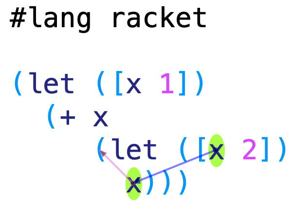

现在来看一个更复杂的例子： Now for a more complex example:

{let1 {x 1}

{+ {let1 {x 2} x}

x}}

这里，借助替换来确定答案尤其有用。同样，左边表达式中的 x 被遮蔽，因而应为 2，这似乎很清楚。当然，关键问题是，加法右侧（也就是最后一行）的 x 怎么办？ Here, it’s especially useful to turn to substitution to determine the answer. Again, it seems clear that x in the left expression is shadowed and hence should be 2 . The big question, of course, is what about the x on the right hand side of the addition (i.e., on the last line)?

在这里，常规文本语法再次充满歧义：左边的 Here, again, conventional textual syntax is fraught with ambiguity: is

x = 2

究竟是绑定一个新的 x，还是修改外层 x？这是两件完全不同的事！但使用我们的语法，就清楚得多：应该是前者，而非后者。因此，通过替换，外层 x 被替换为 1，得到 on the left a binding of a new x or a modification of the outer x ? Those are two very different things! But with our syntax it’s much clearer that it should be the former, not the latter. Thus, by substitution, the outer x is replaced by 1 , giving

{+ {let1 {x 2} x}

1}

在其中再做一次替换，得到 in which we perform one more substitution, producing

{+ 2

1}

所以结果是 3。这次，DrRacket 尤其有助于确认这一点： and hence 3 . This time, DrRacket is especially useful confirmation:

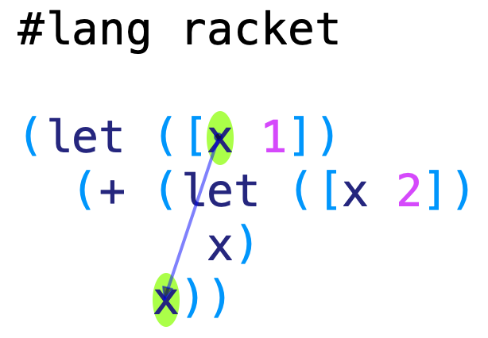

这样就只剩一个程序了： That leaves just one program:

x

由于 x 没有在任何地方绑定，这就是一个语法错误。 Because x is not bound anywhere, this is just a syntax error.

## 静态作用域 Static Scoping

这个程序 The program

{let1 {x 1}

{+ {let1 {x 2} x}

x}}

为我们引出了一个非常重要的概念：事实上，它是 SMoL 背后的核心思想之一。那就是，一个变量的绑定由它在源程序中的位置决定，而不是由程序的执行顺序决定。也就是说，无论求值之前发生了哪些其他绑定，最后一行的 x 都由同一位置绑定——因而获得相同的值。为了更好地理解这一点，来看一系列逐步变化的程序： introduces us to a very important concept: indeed, one of the central ideas behind SMoL. This is that a variable’s binding is determined by its position in the source program , and not by the order of the program’s execution . That is, the x on the last line is bound by the same place—and hence obtains the same value—irrespective of other bindings that took place before it was evaluated. To understand this better, let’s see a progression of programs:

{let1 {x 1}

{+ {let1 {x 2} x}

x}}

你可能觉得，它得到 3 还是 4 都没关系。那这个呢？ You might think it’s okay whether it produces 3 or 4 . How about this?

{let1 {x 1}

{+ {if true

{let1 {x 2} x}

4}

x}}

你应该预期它得到同样的结果：条件总为真，显然我们总会对内层绑定求值，所以它的答案应该与前一个程序相同。但这个呢？ You should expect the same out of this: the conditional is always true, so clearly we are always going to evaluate the inner binding, so its answer should be the same as for the previous program. But how about this?

{let1 {x 1}

{+ {if true

4

{let1 {x 2} x} }

x}}

现在你可能没那么确定了。既然条件分支从不执行，你大概不希望内层绑定产生影响。也就是说，你愿意让程序的控制流影响绑定。乍听之下这很合理，但现在这个程序又如何？ Now you might not be so sure. Since the conditional is never taken, you probably don’t want the inner binding to have an influence. That is, you are willing to let the program’s control flow influence the bindings . On its face that sounds reasonable, but now how about this program?

{let1 {x 1}

{+ {if {random}

4

{let1 {x 2} x}}

x}}

或者 or

{let1 {x 1}

{+ {if {moon-is-currently-full}

4

{let1 {x 2} x}}

x}}

你能接受绑定结构每两周变化一次吗？那这个版本呢： Are you okay with the binding structure changing every two weeks? What about this version:

{let1 {x 1}

{+ {if {moon-is-currently-full}

4

{let1 { y 2} x}}

y }}

这样，取决于月相，程序要么得到一个答案，要么产生未绑定变量错误。 Then, depending on the phase of the moon, the program either produces an answer or results in an unbound-variable error.

上面这一系列代码牵涉到几个不同的概念。其中一些——让控制流决定绑定——是动态作用域的变体。动态作用域是编程语言中一个毫无疑问的错误设计决策。它有一段漫长而不光彩的历史：最初的 Lisp 就采用了它，直到十多年后，Scheme 才修正这个问题。（遗憾的是，不了解历史的人注定要重蹈覆辙：早期的 Python 和 JavaScript 也有某种形式的动态作用域。要将其移除，费了九牛二虎之力。）在上面的程序中，仅凭观察，我们无法确定程序的绑定结构。 There are a few different concepts caught up in the above sequence of code. Some of these—letting the control flow determine binding—are variants of dynamic scope . Dynamic scope is one of the unambiguously wrong design decisions in programming languages. It has a long and sordid history: the original Lisp had it, and it was not until over a decade later that Scheme fixed it. (Unfortunately, those who don’t know history are doomed to repeat it: early versions of Python and JavaScript also had forms of dynamic scope. Taking it back out has been a herculean effort.) In the programs above, we can’t be sure about the binding structure of our programs just by looking at them.

然而，“观察”程序的不只有我们：编程工具也会！例如，程序重构工具需要知道绑定结构：即使一个简单的“变量重命名”工具，也需要知道该重命名哪些变量。在 DrRacket 中，没有歧义，所以变量重命名能正确工作。其他语言却未必如此：例如，可以参看这篇关于 Python 语义的论文的附录 2。 However, we aren’t the only entities that “look” at programs: so do our programming tools! For instance, a program refactoring tool needs to know binding structure: even a simple “variable renaming” tool needs to know which variables to rename. In DrRacket, there is no ambiguity, so variable renaming works correctly. This is not true in other languages: see, for instance, Appendix 2 of [this paper](https://cs.brown.edu/~sk/Publications/Papers/Published/pmmwplck-python-full-monty/) on the semantics of Python.

相比之下，我们想要的是这样一个系统：沿着 AST 的结构就能确定绑定，也就是所谓静态作用域。这样，就不必知道程序将如何运行——运行可能涉及随机数或月相——也能理解作用域结构。例如，这让 IDE 能在受绑定实例与建立绑定的实例之间画出箭头，并对它们重命名。静态作用域是 SMoL 的一个界定性特征。 In contrast, what we want is a system where we can determine the binding by following the structure of the AST: what is called static scope . Then we don’t need to know how a program will run—which may involve references to random numbers or phases of the moon—to understand the scoping structure. This enables, for instance, an IDE to draw arrows between bound and binding instances, and to rename them. Static scope is a defining characteristic of SMoL.

早期语言采用动态作用域，是因为在实现中很容易得到它：它是默认行为。正如将要看到的，实现静态作用域需要我们多费一点工夫。 Early languages had dynamic scope because it was easy to obtain in the implementation: it was the default behavior. We have to work a bit harder to implement static scope, as we will see.

## 局部绑定的求值器 An Evaluator for Local Binding

既然已看清想要的行为，就应该实现它。也就是说，我们将扩展计算器来处理局部绑定（你很可能也希望自己的计算器拥有这个特性）。为了体现计算器正在成长，从现在起，我们称它为解释器，在代码中缩写为 interp。 Now that we’ve seen what behavior we want, we should implement it. That is, we’ll extend our calculator to handle local binding (a feature you may well have wished your calculator had). To reflect that our calculator is growing up, from now on we’ll call it an interpreter , abbreviated in code to interp .

先从新的 AST 开始。为简单起见，忽略条件式，反正它与处理局部绑定的目标是正交的。回想一下，我们在 BNF 中增加了两个新分支，因此 AST 中也需要两个相应的新分支： Let’s start with the new AST. For simplicity, we’ll ignore conditionals, which are anyway orthogonal to our goal of handling local binding. Recall that we added two new branches to the BNF, so we’ll want two new corresponding branches to the AST:

(define-type Exp

[numE (n : Number)]

[plusE (left : Exp) (right : Exp)]

[varE (name : Symbol)]

[let1E (var : Symbol)

(value : Exp)

(body : Exp)])

还可以把之前的计算器复制过来，但很快就会遇到麻烦： We can also copy over our previous calculator, but we pretty quickly run into trouble:

(define (interp e)

(type-case (Exp) e

[(numE n) n]

[(varE s) …]

[(plusE l r) (+ (interp l) (interp r))]

[(let1E var val body) …]))

遇到 let1E 时，该做什么？同样，遇到变量时，又该做什么？事实上，这两者应该紧密相连：前者引入的变量绑定，应当替换后者中的变量使用。 What do we do when we encounter a let1E ? For that matter, what do we do when we encounter a variable? In fact, these two should be intimately connected: the variable binding introduced by the former should substitute the variable use in the latter.

## 缓存替换 Caching Substitution

我们反复地——也理所当然地——借助替换来理解程序应当如何工作，事实上稍后还会再次这样做。但把替换当作求值技术却很麻烦。它要求不断改写程序文本，每次变量绑定所需的时间都与程序大小成线性关系（而程序可能相当大）。大多数实际语言实现并不是这样工作的。 We repeatedly—and rightly—refer back to substitution to understand how programs should work, and indeed will do so again later. But substitution as an evaluation technique is messy. This requires us to constantly keep rewriting the program text, which takes time linear in the size of the program (which can get quite large) for every variable binding. Most real language implementations do not work this way.

相反，可以考虑用空间换时间：使用少量额外空间，省下大量时间。也就是说，把替换缓存在一个称为环境的数据结构中。环境记录名称及其对应的值：也就是说，它是键值对的集合。因此，每当遇到绑定，就记住它的值；遇到变量时，就查找它的值。 Instead, we might think of employing a space-time tradeoff: we’ll use a little extra space to save ourselves a whole lot of time. That is, we’ll cache the substitution in a data structure called the environment . An environment records names and their corresponding values: that is, it’s a collection of key-value pairs. Thus, whenever we encounter a binding we remember its value, and when we encounter a variable, we look up its value.

旁注：和所有缓存一样，我们希望它只在某个维度上改善性能，而不改变含义。也就是说，我们不再希望用替换来定义如何生成答案。但仍然希望它告诉我们应当生成什么答案。这一点在下面会很重要。 Aside: A s with all caches, we want them to only improve performance along a dimension, not change the meaning. That is, we no longer want substitution to define how we produce an answer. But, we still want it to tell us what answer to produce. This will become important below.

我们将用哈希表来表示环境： We will use a hash table to represent the environment:

(define-type-alias Env (Hashof Symbol Value))

(define mt-env (hash empty)) ;; "empty environment"

解释器需要实际接收一个环境作为形式参数，用来取代替换。因此： We will need the interpreter to actually take an environment as a formal parameter, to use in place of substitution. Thus:

(interp : (Exp Env -> Value))

(define (interp e nv) …)

现在，遇到变量时会怎样？我们尝试在环境中查找它。查找可能成功，也可能像上面最后一个例子那样失败。我们会使用 hash-ref，它在哈希表中查找键，并返回 Optionof 类型，以表达失败的可能。可以把它封装进一个之后会反复用到的函数： Now what happens when we encounter a variable? We try to look it up in the environment. That may succeed or, in the case of our last example above, fail. We will use hash-ref , which looks up keys in hash tables, and returns an Optionof type to account for the possibility of failure. We can encapsulate it in a function that we will repeatedly find useful:

(define (lookup (s : Symbol) (n : Env))

(type-case (Optionof Value) (hash-ref n s)

[(none) (error s "not bound")]

[(some v) v]))

如果查找成功，我们就要那个被包裹在 some 中的查找结果。这个函数能让解释器保持非常简洁易读： In the event the lookup succeeds, then we want the value found, which is wrapped in some . This function enables our interpreter to stay very clean and readable:

[(varE s) (lookup s nv)]

最后，可以着手处理 let1 了。这里会发生什么？我们必须 Finally, we are ready to tackle let1 . What happens here? We must

- 对表达式的主体求值，所用的 evaluate the body of the expression, in
- 环境已经扩展，其中 an environment that has been extended, with
- 新的名称 the new name
- 绑定到了它的值。 bound to its value.

呼！ Phew!

幸运的是，这并没有听起来那么糟。同样，一个函数会很有帮助： Fortunately, this isn’t as bad as it sounds. Again, a function will help a lot:

(extend : (Env Symbol Value -> Env))

(define (extend old-env new-name value)

(hash-set old-env new-name value))

有了它，就能清楚看出结构： With this, we can see the structure clearly:

[(let1E var val body)

(let ([new-env (extend nv

（注意，我们在 plait 中使用 let 来定义 let1。之后还会看到更多这种情况……） (Observe that we used let in plait to define let1 . We’ll see more of this…)

总之，核心解释器现在是： In sum, our core interpreter is now:

(define (interp e nv)

(type-case Exp e

[(numE n) n]

[(varE s) (lookup s nv)]

[(plusE l r) (+ (interp l nv) (interp r nv))]

[(let1E var val body)

(let ([new-env (extend nv

var

(interp val nv))])

(interp body new-env))]))

练习： Exercise:

1. 如果上面没有调用 (interp val nv)，会怎样？ What if we had not called (interp val nv) above?
2. 如果调用 interp 时使用 nv 而不是 new-env，会怎样？ What if we’d used nv instead of new-env in the call to interp ?
3. 解释器中还有其他因复制之前的内容而产生的错误吗？ Are there any other errors in the interpreter based on copying what we had before?
4. 我们似乎一直扩展环境，却从不移除任何东西。这样可以吗？如果不可以，就应该会引发错误。什么程序能展示这个错误？它实际上确实会出错吗？（如果不会，为什么？） We seem to extend the environment but never remove anything from it. Is that okay? If not, it should cause an error. What program would demonstrate this error, and does it actually do so? (If not, why not?)

至此，我们第一个有意思的“编程语言”就完成了。我们已经被迫处理了一些相当微妙的作用域问题，以及如何解释它们。从这里起，事情只会越来越有趣！ This concludes our first interesting “programming language”. We have already been forced to deal with some fairly subtle questions of scope, and with how to interpret them. Things will only get more interesting from here!

# 函数求值 Evaluating Functions

现在有了算术和条件式，让我们继续加入函数，创建一种完整的编程语言。 Now that we have arithmetic and conditionals, let’s proceed to creating a full-fledged programming language by adding functions.

## 语言中的函数 Functions in the Language

可以从许多角度考虑如何给语言加入函数。例如，许多语言有顶层函数；比如： There are many ways to think about adding functions to the language. Many languages, for instance, have top-level functions; e.g.:

fun f(x):

x + x

确实，有些语言（例如 C）只有顶层函数。不过，大多数现代语言都能够在顶层之外编写函数：例如， Indeed, some languages (such as C) only have top-level functions. Most modern languages, however, have the ability to write functions outside the top-level: e.g.,

fun f(x):

fun sq(y):

y * y

sq(x) + sq(x)

甚至能返回这些函数，还允许以匿名方式编写它们。由于几乎每一种现代语言都支持这一点，我们将把它视为 SMoL 的一个组成部分。事实上，有了这种能力，就不再真正需要专门的具名函数构造了：我们可以改写成 and even to return those functions, and even to allow them to be written anonymously . Since just about every modern language supports it, we’ll think of this as a component of SMoL. Indeed, with such a facility, we don’t really need a named function construct per se: we could instead have written

fun f(x):

sq = lam(y): y * y

sq(x) + sq(x)

接着，也可以用名称绑定和 lam 来替代 f。 And in turn we can replace f with a name-binding and lam , too.

## 扩展表示 Extending the Representation

因此，来想想在 SMoL 中对作为值的函数求值，需要做些什么。函数本身不必有名称，因为命名可以通过 let1 完成。为简单起见，假设所有函数都只接收一个参数；将其扩展到多个参数，留作练习。 Therefore, let’s think about what it takes to evaluate functions-as-values to SMoL. We don’t need functions to inherently have a name, because naming can be done by let1 . We’ll assume, for simplicity, that all functions take only one argument; extending this to multiple arguments is left as an exercise.

练习：把函数从只有一个参数扩展到多个参数时，可能需要处理哪些问题？ Exercise: What issues might we have to deal with when we extend functions from having one argument only to having multiple arguments?

首先，需要扩展抽象语法。 First, we need to extend our abstract syntax.

现在动手！需要向抽象语法中加入几个新构造？ Do Now: How many new constructs do we need to add to the abstract syntax?

你可能记得，加入 let1 时，只增加一个构造还不够；需要两个：一个用于变量绑定，一个用于变量使用。向语言中加入值时，经常会看到这种模式。对于任何一种新值，通常都应有一种或多种构造它的方式，以及一种或多种使用它的方式。（即便算术也是如此：数字常量是构造数字的方式，算术运算则使用它们——但也会构造它们。） When we added let1 , you may recall that it didn’t suffice to add one construct; we needed two: one for variable binding and one for variable use . You’ll often see this pattern when adding values to the language. For any new kind of value, you can expect to see one or more ways to make it and one or more ways to use it. (Even arithmetic: numeric constants were a way to make them, arithmetic operations consumed them—but also made them.)

函数也一样，我们需要一种方式来同时表示 Likewise with functions, we need a way to represent both

lam(x): x * x

用于定义新函数的构造，以及 for defining new functions, and

sq(3)

用于使用函数的构造。 to use them.

术语：在更高级的书籍中，有时会看到“引入”和“消去”这两个术语（形式上正确，但或许稍有些令人困惑）：引入带来新概念，消去则使用它们。因此，lam 引入新函数，而应用则消去它们。 Terminology: In more advanced texts, you will sometimes see the (formally correct, but perhaps slightly confusing) terms introduction and elimination : introduction brings the new concept in, elimination uses them. Thus, the lam introduces new functions, and an application eliminates them.

因此，我们把 We therefore add

[lamE (var : Symbol) (body : Exp)]

[appE (fun : Exp) (arg : Exp)]

加入 AST。 to our AST.

假设已经扩展了解析器，使下面这样的程序合法： Let’s assume we’ve already extended our parser, so that programs like the following are legal:

{let1 {f {lam x {+ x x}}}

{f 3}}

{let1 {x 3}

{let1 {f {lam y {+ x y}}}

{f 3}}}

它们分别解析成 These parse, respectively, into

(let1E 'f (lamE 'x (plusE (varE 'x) (varE 'x)))

(appE (varE 'f) (numE 3)))

(let1E 'x (numE 3)

(let1E 'f (lamE 'y (plusE (varE 'x) (varE 'y)))

(appE (varE 'f) (numE 3))))

并且都应求值为 6。 and should both evaluate to 6 .

## 函数求值 Evaluating Functions

现在来考虑求值器，到了这一步，可以认为它正演变成一个完整的解释器。 Now let’s think about the evaluator, which by now we can think of as turning into a full-blown interpreter.

先从（几乎）最简单的一种新程序开始： Let’s start with the (almost) simplest kind of new program:

{lam x {+ x x}}

它表示为 which is represented as

(lamE 'x (plusE (varE 'x) (varE 'x)))

现在动手！我们希望这个程序求值为什么？从类型的角度想一想！ Do Now: What do we want this program to evaluate to? Think in terms of types!

记住，calc 生成数字。上面的表达式求值为哪个数字？你期望它生成哪个数字？ Remember that calc produces numbers. What number does the above expression evaluate to? What number do you expect it to produce?

如果真要勉强找个说法，可以编造一种把它编码成数字的方法，或者使用内存中的某个数字。但这两者都不是我们期望的！来看看其他一些语言怎么做： If we really want to stretch our credibility, we could either make up an encoding of it in a number, or use a number in memory. But neither of these is what we would expect ! Let’s look at what some other languages do:

> (lambda (x) (+ x x))

#<procedure>

> (number? (lambda (x) (+ x x)))

#f

>>> lambda x: x + x

<function <lambda> at 0x108fd16a8>

>>> isinstance(lambda x: x + x, numbers.Number)

False

Racket 和 Python 的做法一致：创建匿名函数的结果是函数这一类值，而不是数字。这意味着，必须扩大 interp 可以生成的值的种类。 Both Racket and Python agree: the result of creating an anonymous function is a function-kind of value, not a number. What this says is that we have to broaden the kinds of values that interp can produce.

术语：副作用，是指对系统作出的、在函数体外部可见的改变。典型的副作用包括修改在函数外部定义的变量、与网络通信、修改文件，等等。 Terminology: A side-effect is a change to the system that is visible from outside the body of a function. Typical side-effects are modifications to variables that are defined outside the function, communication with a network, changes to files, and so on.

术语：如果函数对于给定输入，总是生成相同输出，并且没有副作用，就称它是纯的。实际上，计算总会有一些副作用，例如消耗能量和产生热量，但由于这些现象普遍存在，我们通常忽略它们。不过，在少数场景中，它们可能很重要：例如，如果通过测量这些副作用就能窃取加密密钥。 Terminology: A function is pure if, for a given input, it always produces the same output, and has no side-effects. In reality, a computation always has some side-effects, such as the consumption of energy and production of heat, but we usually overlook these because they are universal. In a few settings, however, they can matter: e.g., if a cryptographic key can be stolen by measuring these side-effects.

术语：传统上，有些语言使用“过程”和“函数”来表示相似但不相同的概念。两者都是类似函数的实体，封装了一段代码体，并且可以被应用（或“调用”）。过程是一种不生成值的封装；因此，它必须有副作用才有用。相比之下，函数总会生成一个值（而且可能被期望没有任何副作用）。多年来，这套术语已经彻底混乱，人们现在常把两者混用，但如果有人似乎在区分它们，大概指的就是上述区别。 Terminology: Traditionally, some languages have used the terms procedure and function for similar but not identical concepts. Both are function-like entities that encapsulate a body of code and can be applied (or “called”). A procedure is an encapsulation that does not produce a value; therefore, it must have side-effects to be of any use. In contrast, a function always produces a value (and may be expected to not have any side-effects). This terminology has gotten completely scrambled over the years and people now use the terms interchangeably, but if someone seems to be making a distinction between the two, they probably mean something like the above.

## 扩展值 Extending Values

对函数求值时会发生什么？Racket 和 Python 似乎都表明，我们返回一个函数。 What happens when evaluating a function? Both Racket and Python seem to suggest that we return a function.

我们可以不保留关于函数的任何额外信息： We could have no additional information about the function:

(define-type Value

[numV (the-number : Number)]

[boolV (the-boolean : Boolean)]

[funV])

（这个语法表示 funV 是一个没有参数的构造器。除了说明它是 funV 这一事实之外，不传递任何信息；由于不能混用类型，具体来说，它表示一个值不是数字，也不是布尔值——仅此而已。）但现在想想下面这样的程序（假设 x 已绑定）： (That syntax means funV is a constructor of no parameters. It conveys no information at all other than the fact that it’s a funV ; because we can’t mix types, it says, in particular, that a value is not numeric or a Boolean—and nothing more.) But now think about a program like this (assuming x is bound):

{{if0 x

{lam x {+ x 1}}

{lam x {- x 2}}}

5}

两种情况下，都会得到一个不含额外信息的 funV 值，因此当我们尝试执行应用时，就……做不到。 In both cases we’re going to get a funV value with no additional information, so when we try to perform the application, we…can’t.

相反，显然函数值必须告诉我们有关函数的信息。需要知道函数体，因为那是要进行求值的部分；但函数体可以（而且很可能会）引用形式参数的名称，因此也需要这个名称。所以，真正需要的是 Instead, it’s clear that the function value needs to tell us about the function. We need to know the body, because that’s what we need to evaluate; but the body can (and very likely does) reference the name of the formal parameter, so we need that too. Therefore, what we really need is

(define-type Value

[numV (the-number : Number)]

[boolV (the-boolean : Boolean)]

[funV (var : Symbol) (body : Exp)])

到了这一步，我们似乎白费了许多工夫。拿到数字和布尔值，只是用新构造器重新包裹一遍，现在对函数也做同样的事。这让人想到莎士比亚某部戏剧的名字。 At this point, it seems like we’ve gone to a lot of trouble for nothing. We take numeric and Boolean values and simply re-wrap them in new constructors, and now we’re doing the same thing for functions. A certain Shakespeareian play’s title comes to mind.

耐心点。 Patience.

凭借现有内容，已经能得到一个可运行的解释器了。lam 的情况显然非常简单： With what we have, we can already have a functioning interpreter. The lam case is obviously very simple:

[(lamE v b) (funV v b)]

应用的情况稍微复杂一些。我们需要： The application case is a bit more detailed. We need to:

1. 对函数位置求值，弄清它是哪一类值。 Evaluate the function position, to figure out what kind of value it is.
2. 对参数位置求值，因为我们已经约定 SMoL 就是这么做的。 Evaluate the argument position, since we’ve agreed that’s what happens in SMoL.
3. 检查函数位置是否确实求值为函数。如果不是，抛出错误。 Check that the function position really does evaluate to a function. If it does not, raise an error.
4. 对函数体求值。但由于函数体可以引用形式参数…… Evaluate the body of the function. But because the body can refer to the formal parameter…
5. ……先确保形式参数已绑定到实际参数的值。 …first make sure the formal is bound to the actual value of the argument.

分阶段把这些写成代码： Codifying this, in stages:

[(appE f a) (let ([fv (interp f nv)]

[av (interp a nv)])

…) ]

[(appE f a) (let ([fv (interp f nv)]

[av (interp a nv)])

(type-case Value fv

[(funV v b) …]

[else (error 'app "didn't get a function")] ))]

[(appE f a) (let ([fv (interp f nv)]

[av (interp a nv)])

(type-case Value fv

[(funV v b)

(interp b …) ]

[else (error 'app "didn't get a function")]))]

[(appE f a) (let ([fv (interp f nv)]

[av (interp a nv)])

(type-case Value fv

[(funV v b)

(interp b (extend nv v av) )]

[else (error 'app "didn't get a function")]))]

## 退后一步 Stepping Back

把这一切组合起来，得到如下解释器： Putting it all together, we get the following interpreter:

(interp : (Exp Env -> Value))

(define (interp e nv)

(type-case Exp e

[(numE n) (numV n)]

[(varE s) (lookup s nv)]

[(plusE l r) (add (interp l nv) (interp r nv))]

[(lamE v b) (funV v b)]

[(appE f a) (let ([fv (interp f nv)]

[av (interp a nv)])

(type-case Value fv

[(funV v b)

(interp b (extend nv v av))]

[else (error 'app "didn't get a function")]))]

[(let1E var val body)

(let ([new-env (extend nv

var

(interp val nv))])

(interp body new-env))]))

练习：上面写出了一个特定顺序，并在代码中落实了它。但这与实际语言采用的顺序相同吗？具体来说，非函数错误是在对参数求值之后还是之前报告？做实验找出答案！ Exercise: We wrote down a particular ordering above, which we put into practice in the code. But is that the same ordering that actual languages use? In particular, are non-function errors reported after or before evaluating the argument? Experiment and find out!

走过好几个步骤才到这里，很容易忘记我们刚刚完成了什么。只用 20 行代码（外加几个辅助函数），我们就描述了一种完整编程语言的实现。不仅如此，这种语言还能够表达所有计算。图灵奖得主 Alan Kay 首次看到等价的程序时，他说： Since we’ve taken several steps to get here, it’s easy to lose sight of what we’ve just done. In just 20 lines of code (with a few helper functions), we have described the implementation of a full programming language . Not only that, a language that can express [all computations](https://en.wikipedia.org/wiki/Church%E2%80%93Turing_thesis) . When Turing Award winner [Alan Kay](https://en.wikipedia.org/wiki/Alan_Kay) first saw the equivalent program, [he says](https://queue.acm.org/detail.cfm?id=1039523) ,

是的，那是我读研究生时的一次重大启示——我终于明白，Lisp 1.5 手册第 13 页底部那半页代码，本身就是 Lisp。这就是“软件的麦克斯韦方程组”！整个编程世界，就在这几行我一只手便能盖住的代码里。 Yes, that was the big revelation to me when I was in graduate school—when I finally understood that the half page of code on the bottom of page 13 of the Lisp 1.5 manual was Lisp in itself. These were “Maxwell’s Equations of Software!” This is the whole world of programming in a few lines that I can put my hand over.

我意识到，每当想弄清自己在做什么时，只需用半页纸写下这个东西的内核，就丝毫不会损失能力。事实上，它的能力反而会增强，因为它能够更容易地重新进入自身，而大多数采用另一种方式构建的系统根本做不到这一点。 I realized that anytime I want to know what I’m doing, I can just write down the kernel of this thing in a half page and it’s not going to lose any power. In fact, it’s going to gain power by being able to reenter itself much more readily than most systems done the other way can possibly do.

我们刚刚重新发现了同一个优美而强大的思想！如果想看原版，这就是那本手册（作者为 McCarthy、Abrahams、Edwards、Hart、Levin）。下面是复制的内容： We’ve just rediscovered this same beautiful, powerful idea! If you want to see the original, here’s [that manual](https://www.softwarepreservation.org/projects/LISP/book/LISP%201.5%20Programmers%20Manual.pdf) (by McCarthy, Abrahams, Edwards, Hart, Levin). Here it is, copied:

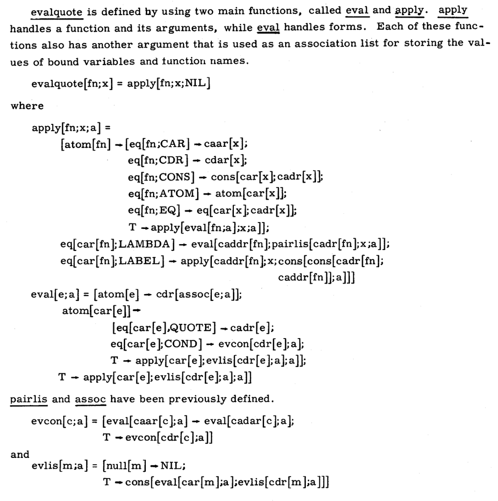

好了，现在我们有了一个针对完整语言的、可运行的解释器。但在确信这一点之前，应该再试几个例子，确认现有结果确实令人满意。 Alright, so we now have a working interpreter for a full-fledged language. But before we can feel sure of that, we should try a few more examples to confirm that we’re happy with what we have.

## 扩充测试 Extending Tests

嗯，其实我们不应该太高兴。考虑以下例子： Well, actually, we shouldn’t be too happy. Consider the following examples:

(let1E 'x (numE 1)

(let1E 'f (lamE 'y (varE 'x))

(let1E 'x (numE 2)

(appE (varE 'f) (numE 10)))))

我们预期它得到什么结果？如果拿不准，可以把同样的内容写成一个 Racket 程序： What do we expect it to produce? If in doubt, we can write the same thing as a Racket program:

(let ([x 1])

(let ([f (lambda (y) x)])

(let ([x 2])

(f 10))))

我们看到，在 Racket 中，内层 x 的绑定不会覆盖外层的绑定，也就是定义绑定给 f 的那个函数时存在的绑定。因此，这在 Racket 中得到 1。 What we see is that in Racket , the inner binding of x does not override the outer one, the one that was present at the time the function bound to f was defined. Therefore, this produces 1 in Racket.

这应该正是我们想要的！否则，考虑这个程序： We should want this! Otherwise, consider this program:

(let1E 'f (lamE 'y (varE 'x))

(let1E 'x (numE 1)

(appE (varE 'f) (numE 10))))

它对应于 This corresponds to

(let ([f (lambda (y) x)])

(let ([x 1])

(f 10)))

其中存在一个未绑定标识符（x）错误。但我们的解释器却得到 1，而不是报错并停止，这就把我们直接带回了 ☠️ 动态作用域 ☠️！ which has an unbound identifier ( x ) error. But our interpreter produces 1 instead of halting with an error, which leads us right back to ☠️ dynamic scope ☠️!

## 回到静态作用域 Return to Static Scope

练习：在 Stacker 中运行以下程序。 Exercise: Run the following programs in the Stacker.

那么，如何修复这个问题？上面的例子实际上给了一条线索，但还有另一个灵感来源。记得我们是从替换开始的吗？我们将在 Racket 中逐步走过这些例子，这样你就能直接运行每个例子，检查它们是否得到相同答案。再次考虑这个程序： So how do we fix this? The examples above actually give us a clue, but there is another source of inspiration as well. Do you remember that we started with substitution ? We’ll walk through these examples in Racket, so that you can run each of them directly and check that they produce the same answer. Consider again this program:

(let ([x 1])

(let ([f (lambda (y) x)])

(let ([x 2])

(f 10))))

用 1 替换 x，得到： Substituting 1 for x produces:

(let ([f (lambda (y) 1)])

(let ([x 2])

(f 10)))

替换 f，得到： Substituting f produces:

(let ([x 2])

((lambda (y) 1) 10))

最后，用 2 替换 x，得到（注意，程序中已经没有任何 x 了！）： Finally, substituting x with 2 produces (note that there are no x s left in the program!):

((lambda (y) 1) 10)

这样看，就清楚为什么后来对 x 的绑定不应产生影响了：那是另一个 x，而先前的 x 实际上已经被替换了。既然已经认定替换就是我们希望程序遵循的工作方式，那么现在的任务就是确保环境确实正确地实现了这一点。 When you see it this way, it’s clear why the later binding of x should have no impact: it’s a different x , and the earlier x has effectively already been substituted. Since we have agreed that substitution is how we want our programs to work, our job now is to make sure that the environment actually implements that correctly .

方法是认识到，环境表示尚待进行的替换，然后把它们记住。也就是说，函数的表示还需要记录创建函数那一刻的环境： The way to do it is to recognize that the environment represents the substitutions waiting to happen, and just remember them. That is, our representation of a function needs to also keep track of the environment at the moment of function creation:

(define-type Value

[numV (the-number : Number)]

[boolV (the-boolean : Boolean)]

[funV (var : Symbol) (body : Exp) (nv : Env) ])

这种新的、内容更丰富的 funV 值有个专门的名字：闭包。这是因为，表达式在其定义时的环境之上被“闭合”起来了。 This new and richer kind of funV value has a special name: it’s called a closure . That’s because the expression is “closed” over the environment in which it was defined.

术语：闭项是不含未绑定变量的项。函数体可能有未绑定变量——例如上面的 x——但闭包确保它们并非真正未绑定，因为它们可以从存下来的环境中取得值。 Terminology: A closed term is one that has no unbound variables. The body of a function may have unbound variables—like x above—but the closure makes sure that they aren’t really unbound, because they can get their values from the stored environment.

引语：“拯救环境！今天就创建一个闭包吧！”——Cormac Flanagan Quote: “Save the environment! Create a closure today!” — [Cormac Flanagan](https://users.soe.ucsc.edu/~cormac/)

引语：“Lambda 一直默默无闻，直到 Java 因为没有它们而让它们走红。”——James Iry，《一部简短、不完整且大多错误的编程语言史》 Quote: “Lambdas are relegated to relative obscurity until Java makes them popular by not having them.” — James Iry, [A Brief, Incomplete, and Mostly Wrong History of Programming Languages](http://james-iry.blogspot.com/2009/05/brief-incomplete-and-mostly-wrong.html)

这意味着，创建闭包时，必须记录创建当时的环境： That means, when we create a closure, we have to record the environment at the time of its creation:

[(lamE v b) (funV v b nv )]

最后，使用函数（由闭包表示）时，必须确保使用存下来的环境，而不是函数调用点存在的环境，后者是动态的环境： Finally, when we use a function (represented by a closure), we have to make sure we use the stored environment, not the one present at the point of calling the function, which is the dynamic one:

[(appE f a) (let ([fv (interp f nv)]

[av (interp a nv)])

(type-case Value fv

[(funV v b nv )

(interp b (extend nv v av))]

[else (error 'app "didn't get a function")]))]

说清楚一点：在上面的代码中，funV 分支中的 nv 有意遮蔽了解释器顶端绑定的 nv。因此，对 extend 的调用扩展的是来自闭包的环境，而不是调用点存在的环境。 Just to be clear: in the code above, the nv in the funV case intentionally shadows the nv bound at the top of the interpreter. Thus, the call to extend extends the environment from the closure , rather than the one present at the point of the call.

练习：注意，函数表达式和参数表达式（分别是 f 和 a）在传给解释器的环境中求值，而不是在闭包内部的环境中。这正确吗？还是应该使用闭包的环境？ Exercise: Notice that the function and argument expressions ( f and a , respectively) are evaluated in the environment given to the interpreter, not the one inside the closure. Is this correct? Or should they be using the closure’s environment?

可以做两件事：从第一性原理出发论证，或者用例子论证。对于后者，你要修改解释器，让它采取另一个选择。然后使用一个示例输入，使其根据所用环境的不同而得到不同答案，指出哪个答案正确（展示等价的 Racket 程序会得到什么结果，是一种不错的论证），再据此说明为什么应选择那个环境。提示：其中一个需要从第一性原理出发论证，另一个应该能够用程序来论证。 You can do two things: argue from first principles or argue with examples. In the latter case, you would modify the interpreter to make the other choice. You would then use a sample input that produces different answers depending on which environment is used, indicate which one is correct (showing what the equivalent Racket program would produce can be a good argument), and use that to justify the chosen environment. Hint: One of these you will need to argue from first principles, the other you should be able to argue using a program.

## 一个微妙的测试 A Subtle Test

在上面的例子中，我们总是在定义闭包的作用域内使用它。然而，我们的语言实际上更强大：可以返回一个闭包，并在定义它的作用域之外使用它。下面是一个 Racket 程序示例： In the examples above, we always use the closure in the scope in which it was defined. However, our language is actually more powerful than that: we can return a closure and use it outside the scope in which it was defined. Here’s a sample Racket program:

((let ([x 3])

(lambda (y) (+ x y)))

4)

现在动手！花点时间仔细阅读。它应该得到什么结果？ Do Now: Take a moment to read it carefully. What should it produce?

首先绑定 x，然后对 lambda 求值。这会创建一个记住 x 的绑定的闭包。这个闭包就是下面这个表达式返回的值： First we bind the x , then we evaluate the lambda. This creates a closure that remembers the binding to x . This closure is the value returned by this expression:

( (let ([x 3])

(lambda (y) (+ x y)))

4)

接着，把这个值应用于 4。这样做是合法的，因为返回的值是一个函数。将它应用于 4 时，会对 4 与 3 的和求值，得到 7。果然，把它翻译后交给我们的解释器，得到 7： This value is now applied to 4 . It’s legal to do this, because the value returned is a function. When we apply it to 4 , that evaluates the sum of 4 and 3 , producing 7 . Sure enough, translating this and sending it to our interpreter produces 7 :

(test (interp (appE (let1E 'x (numE 3)

(lamE 'y (plusE (varE 'x) (varE 'y))))

(numE '4))

mt-env)

(numV 7))

练习：这里还有一个值得尝试的测试，写成了 Racket 程序： Exercise: Here’s another test to try out, written as a Racket program:

((let ([y 3])

(lambda (y) (+ y 1)))

5)

它在 Racket 中得到什么结果？将它翻译后，在你的解释器中试一试。 What does it produce in Racket? Translate it and try it in your interpreter.

# ••••• 语法糖 ••••• ••••• Syntactic Sugar •••••

我们现在已经看到了一个小型核心语言的精髓。在实践中，编程语言还需要好用。为此，它们必须提供让编程更方便的功能。我们将看到，它们可以在尽量减少自身工作量和痛苦的同时做到这一点。 We have now seen the essence of a small core language. In practice, programming languages need to also be usable . To do this, they have to provide features that make programming convenient. We will see they can do this while minimizing their effort and pain.

# SMoL 如何变大 How SMoL Becomes Large

我们已经介绍过 SImPl，即标准实现方案。其核心思想是：用一个（相互）递归的代数数据类型，将程序的语法表示为抽象语法，然后编写一个类似的（相互）递归程序来处理它。这个程序产生什么，取决于我们想要实现的处理过程：解释器产生值，编译器产生程序（用另一种语言编写），类型检查器产生关于类型正确性的判断（以及更多内容，我们很快就会看到），等等。不过，它们都有相同的基本结构。 We have already been introduced to the idea of SImPl, the Standard Implementation Plan. The core idea is that the program’s syntax is represented as abstract syntax using a (mutually) recursive algebraic datatype, and we then write a similar (mutually) recursive program to process it. What that program produces depends on the process we are trying to implement: an interpreter produces values , a compiler produces programs (in another language), a type-checker produces judgments about type-correctness (and more, as we’ll soon see), and so on. But they all have the same basic structure.

实际上，这意味着 SImPl 必须为语言中的每一种构造提供一个处理分支。这在原则上不是问题，但实践中可能变得很繁重。假设有两种构造，其中包含大量重复内容。这不仅意味着我们必须重复编程，还意味着我们必须重复维护：如果在其中一处修复了一个错误，就必须记得在另一处以相应方式修复它。 In practice, this means that a SImPl needs to have a case to handle each of the constructs in the language. This is not a problem in principle, but it can become onerous in practice. Suppose we have two constructs that have a lot of repetition. Not only does it mean we have to duplicate programming, it also means we have to duplicate maintenance : if we fix a bug in one, we have to remember to fix it in the other in the corresponding way.

## 语言中的冗余 Redundancy in Languages

我们会在哪里发现这样的冗余呢？现实语言中有好几个例子。例如，许多语言既有 for 循环，也有 while 循环。考虑一个典型的 C 语言 for 循环： Where might we find such redundancy? There are several examples in real languages. For instance, many languages have both for and while loops. Consider a typical for loop in C:

for(x = 0; x < 10; x++) {

sum += x;

}

这与下面的代码完全相同 This is exactly the same as

x = 0;

while (x < 10) {

sum += x;

x++;

}

事实上，这里有一个一般模式： There is, in fact, a general pattern:

for(INITIAL; CONDITIONAL; UPDATE) {

sum += x;

}

与下面的代码相同（语法上稍作变通） is the same (with some syntactic liberties) as

INITIAL;

while (CONDITIONAL) {

sum += x;

UPDATE;

}

现在，设想你要为此编写一个解释器。显然，while 循环的实现必须进行若干次递归调用、迭代、检查，或许还要做一些其他簿记工作（甚至可能要管理作用域的临时扩展）。对于 for，所有这些工作都得再做一遍！如果只实现一次，再把 for 的主体翻译为 while 的主体，岂不是简单得多？ Now imagine you’re writing an interpreter for this. Clearly, the while loop’s implementation has to make several recursive calls, iterate, check, and perhaps perform some other bookkeeping (and maybe even manage temporary scope extensions). All of that work has to be duplicated for for ! Wouldn’t it be much simpler to instead implement it just once, and translate the for body into a while body?

那为什么还要同时保留这两种构造呢？因为它们各自在不同用途下都很方便。特别是，while 有一种特定风格的用法，如果混在一大堆 while 代码里就较难辨认，而 for 会自动为我们把它归类出来。这丰富了我们作为程序员的词汇，只不过也恰好增加了我们作为实现者的痛苦。我们希望获得便利和更丰富的词汇，却不想承受这份痛苦。 Why have both constructs at all? Because each one is convenient for different purposes. In particular, there’s a certain stylistic use of while that would be harder to spot from a mass of while code that is automatically classified for us with for . It adds to our vocabulary as programmers. It just happens to also add to our pain as implementors. We’d like the convenience and richer vocabulary without the pain.

## 脱糖 Desugaring

由此就引出了核心语言和表层语言的区别。表层语言可以提供各种便利，但它们都会被翻译成核心语言，而核心语言的构造则全都直接处理。那些让编程变得更“甜”的额外构造，就叫作语法糖。将表层程序翻译为核心程序的程序叫作脱糖器，因为它会去掉糖。（原则上，脱糖器其实是一个从表层语言到核心语言的编译器。不过，由于核心语言是表层语言的子语言，这是一种非常特殊的编译情形，因此我们觉得，值得用一个专门的术语将它与一般编译区分开。就像我们觉得，值得用一个专门的术语将 for 与一般的 while 区分开一样……） This introduces a distinction between a core language and a surface language. The surface language may have various conveniences, but these get translated into the core language, whose constructs are all handled directly. The extra constructs—those that make it “sweeter” to program—are called syntactic sugar . The program that translates surface programs down to the core is called a desugarer , because it removes sugar. (In principle, a desugarer is actually a compiler from the surface language to the core language. However, since the core language is a sub -language of the surface, this is a very special case of compilation, and we find it useful to have a special term to distinguish it from general compilation. Just like we find it useful to have a special term to distinguish for from the general while …)

旁注：在实际实现中，这种编译需要更加小心。假如你在使用 for 时犯了一个错误，报错信息却用 while 来描述，你就会很困惑，因为你根本没有输入过 while。特别是，你可能还是一个甚至不知道 while 是什么的学生！现代脱糖系统，比如 Racket 中的系统，都有专门的支持，能够处理大多数常见情况下的这类问题。 Aside: In a real implementation, this compilation requires a little more care. Suppose you make an error using for , but the error was reported in terms of while : you’d be pretty confused, because you never did type the while . As a special case, you may be a student who doesn’t even know what while is ! Modern desugaring systems, such as that in Racket, have special support to take care of this in most of the common cases.

现实语言中的脱糖其实还有很多。例如，and 和 or 可以脱糖为嵌套的 if。在 JavaScript 中，o.x 会脱糖为 o["x"]（这一点过一会儿就会用到）。在许多语言中，x += y 是 x = x + y 的语法糖。在 Python 中，+ 会脱糖为 __add__ 方法。事实上，Python 有一大堆这样的脱糖；这些方法叫作“dunder”方法（double-underscore，即双下划线的缩写），围绕它们还发展出了一整套“协议”编程风格。许多语言（例如 Haskell 和 Python）都有列表推导式，它们会脱糖为函数调用和方法调用。诸如此类。简而言之，脱糖在编程中无处不在。如果你没注意到它，这在某种程度上正是它的目的：你感觉自己使用的表层语法，比实现者需要管理的语法更大。 There are actually many more desugarings in real languages. For instance, and and or can desugar into nested if s. In JavaScript, o.x desugars into o["x"] (which will be relevant in a while). In many languages, x += y is sugar for x = x + y . In Python, + desugars into the method __add__ . In fact, Python has a whole bunch of these desugarings; these methods are called “dunder” methods (short for double-underscore), and a whole programming style of “ [protocols](https://twitter.com/gvanrossum/status/1307712322320785409) ” has evolved around it. Many languages (like Haskell and Python) have list comprehensions, which desugar into function and method calls. And so on. In short, desugaring is everywhere in programming. If you don’t notice it, that’s part of the point: it feels like you’re working with a larger surface syntax than the implementor has to manage.

实现脱糖的方法有很多。一种方法是照常解析程序，然后将 AST 重写为同一种 AST 的一个子集。但在有些语言中，尤其是采用括号语法的语言中，解析分为两个层次：较粗的括号层次和较细的 AST 层次。这意味着我们可以对括号项进行重写，而内部 AST 完全不必知道那些语法糖（也就是说，它只需要涵盖核心语言）。这样的系统通常叫作宏系统：它们在解析之前，将程序源代码（略作抽象）重写为程序源代码。重要的是要理解，大多数语言都有语法糖，但极少有语言提供宏系统，直接把程序重写能力交给程序员，而不是将它藏在编译器内部。 There are many ways in which desugaring can be implemented. One way is to parse the program normally, then rewrite the AST into a subset of the same AST. But in some languages, especially those with parenthetical syntax, there are two levels of parsing: the coarser parenthetical level and the finer level of ASTs. This means we can perform rewriting on the parenthetical terms, and the internal AST never needs to know about the sugars (i.e., it need cover only the core language). These are typically called macro systems: systems in which program source (slightly abstracted) is rewritten into program source, before parsing takes place. It’s important to understand that most languages have syntactic sugar, but very few languages have macro systems, which provide program rewriting capabilities directly to the programmer (as opposed to hiding them inside the compiler).

## 通过示例学习宏 Macros By Example

Racket 是少数拥有宏系统的语言之一，而且它的宏系统非常强大。它的罕见意味着，我们通过宏学到的思想，需要费些工夫才能移植到其他语言；但它的强大意味着，我们可以借助 Racket 的全部能力编写相当复杂的系统，而我们也确实会这样做。本质上，Racket 宏会把一种扩展版 Racket——你愿意的话，可以叫它 Racket++——编译为 Racket，随后我们就可以充分利用现有 Racket 框架的能力。 Racket is one of the few languages to have a macro system, and in fact has a very powerful one. Its rarity means ideas we learn using macros will take some effort to port to other languages; but its power means we can write quite sophisticated systems by leveraging the full power of Racket, and we will do so. In essence, Racket macros compile an extended version of Racket—call it Racket++, if you like—down to Racket, where we can then exploit the full power of the existing Racket framework.

我们将通过一系列示例介绍 Racket 的宏系统。在下面的内容中，请改用 We will introduce the Racket macro system through a series of examples. In what follows, please switch to using

#lang racket

因为 plait 的限制和类型虽然非常适合编写解释器，却会妨碍我们接下来要编写的某些内容。 because the restrictions and types of plait , while very useful for writing interpreters, can get in the way of some of what we’ll write.

## 一种新的条件构造 A New Conditional

回想一下，Racket 是一种使用真性值／假性值的语言，if 将任何非假值都视为真。假设我们想要一个只接受布尔值的严格 if。也就是说，我们希望为 Racket 本身扩展一个 strict-if。来试试这个： Recall that Racket is a truthy/falsy language, where if takes any non-false value to be true. Suppose we want a strict if that takes only Booleans. That is, we want to extend Racket itself with a strict-if . Let’s try this:

(define (strict-if C T E)

(if (boolean? C)

(if C T E)

(error 'strict-if "expected a boolean")))

试试这样的例子： Try examples like:

(strict-if true 1 2)

(strict-if 0 1 2)

看起来正如我们所愿！ Seems to work as desired!

现在动手！你看出问题在哪里了吗？ Do Now: Do you see what the problem is?

问题在于，我们使用的是一种急切求值的语言（SMoL 总体上都是如此！），因此 strict-if 的参数会在函数体开始执行前求值。但是，条件构造的全部意义就是避免对求值过程中的一部分进行求值：试试 The problem is that we have an eager language (this is true of SMoL in general!), so strict-if s arguments are going to be evaluated before the body begins to execute. However, the whole point of a conditional is to avoid evaluating part of the evaluation: Try

(strict-if true 1 (/ 1 0))

将它与下面代码的行为比较一下 Compare this to what happens with

(if true 1 (/ 1 0))

好吧，所以我们无法用函数来达到这个目的。我们需要另一种定义机制，它接收语法并重写语法，而不是立即让它求值。这就是宏。 Okay, so we can’t use functions for this purpose. We need some other definition mechanism that consumes the syntax and rewrites that, instead of letting it evaluate right away. These are macros.

让我们深入看看宏是怎么写的，因为它与函数的写法并没有那么不同： Let’s dive into how the macro is written, because it’s not so different from the function:

(define-syntax strict-if

(syntax-rules ()

[(strict-if C T E)

(if (boolean? C)

(if C T E)

(error 'strict-if "expected a boolean"))]))

这些部分分别是什么？define-syntax 表示我们在定义一种新的语法，而不是函数。syntax-rules 引入一个模式匹配器（暂时忽略 () 的含义，不过你确实需要把它写上）。每条规则都放在方括号中，由一个模式和一个输出组成：如果输入匹配该模式，那么脱糖器（在这里叫作宏展开器）就产生相应的输出，但模式中的名称（此处为 C、T 和 E）会作为程序源代码复制到输出中。因此，对于 What are the pieces? define-syntax says we’re defining a new piece of syntax (as opposed to a function). syntax-rules introduces a pattern-matcher (for now, ignore what the () means: but you do need to include it). Each rule, in brackets, is a pattern and output: if the input matches the pattern, then the desugarer (here called a macro expander ) produces the corresponding output, but with the names in the pattern (here, C , T , and E ) copied as program source into the output. Thus, given

(strict-if true 1 (/ 1 0))

上面的宏定义会将它转换为 the above macro definition transforms it into

(if (boolean? true)

(if true 1 (/ 1 0))

(error 'strict-if "expected a boolean"))

随后，它的求值结果就完全符合我们的预期。 which then evaluates exactly as we’d expect.

Racket 的一个好用功能是宏步进器（Macro Stepper）（）。它会展示程序逐步展开的过程，对于理解宏和调试宏都很有用。如果有必要，请将左下角的“Macro hiding”选项改为“Standard”。 One nice feature of Racket is the Macro Stepper ( ). It shows the program expanding step-by-step, which is useful both for understanding macros and debugging them. If necessary, change the “Macro hiding” option at the bottom-left to read “Standard”.

练习：用上面的宏定义和用法试试它，看看会得到什么。观察它如何在每一步中先高亮即将展开的宏用法，再高亮展开结果。 Exercise: Try it out with the above macro definition and use. See what you get. Observe how, at each step, it highlights the macro use about to be expanded followed by the result of that expansion.

注意：宏步进器不是求值器。它不会显示求值步骤，只会显示展开步骤！因此，如果你编写的程序会在运行时产生错误，宏步进器不会显示该错误。它只显示语法错误。 Note: The Macro Stepper is not an evaluator . It does not show the steps of evaluation, only the steps of expansion! Thus, if you write a program that will produce an error at run-time, the Macro Stepper does not show that error. It only shows syntax errors.

注意：第一次使用宏步进器时，请检查左下角的“Macro hiding”菜单。如果它不是 Standard，就改成 Standard。否则，你会看到许多对学习宏没有帮助的步骤。最终，你可能会遇到足够棘手的程序，需要使用 Disable hiding 或 Custom hiding，但大多数时候，Standard 都最方便、最有用。 Note: When you first use the Macro Stepper, check the “Macro hiding” menu at the bottom-left. If it is not set to Standard, change it to Standard. Otherwise you will see many more steps than are useful for learning about macros. Eventually, you may have a sufficiently thorny program that makes you Disable hiding or use Custom hiding, but most of the time, Standard is the most convenient and useful.

## 局部绑定 Local Binding

现在，来看看我们一直在使用的 let 绑定。设想我们希望为 Racket 扩展一种 let1 构造：例如，我们希望 Now let’s look at the let bindings we’ve been using until now. Imagine we want to extend Racket with a let1 construct: for example, we want

(let1 (x 3) (+ x x))

求值得到 6。 to evaluate to 6.

现在动手！let1 能定义为函数吗？为什么能，或者为什么不能？ Do Now: Can let1 be defined as a function? Why or why not?

let1 不可能是函数。如果它是函数，我们就会先尝试将各个子项作为参数求值。这里有两个看起来像参数表达式的东西：(x 3) 和 (+ x x)。假设我们尝试对 (x 3) 求值。首先，它看起来像一次应用。其次，x 甚至没有被绑定。第三，它无法产生任何有意义的“值”：它唯一的职责其实是绑定 x。不，let1 也是一种新的语法。 let1 can’t be a function. If it were, we would first try to evaluate each of the sub-terms as arguments. There are two things here that look like argument expressions: (x 3) and (+ x x) . Suppose we try to evaluate (x 3) . First of all, it looks like an application. Second, x isn’t even bound. Third, there is no meaningful “value” it could produce: its only job is instead to bind x . No, let1 is also a new piece of syntax.

术语：我们经常将这些新的语法称为构造（比如“一种新的语言构造”）。在 Lisp/Scheme/Racket 社区中，它们有时也叫作特殊形式，因为它们是具有自身特殊绑定规则和求值规则的语法形式。 Terminology: We will often refer to these new pieces of syntax as constructs (as in, “a new language construct”). In the Lisp/Scheme/Racket community, these are sometimes also called special forms , because they are syntactic forms with their own special rules for binding and evaluation.

从现在起，我们会给宏加上 my- 前缀，因为不想与 Racket 内置宏的名称冲突。 From now on we’ll use the prefix my- on our macros, because we don’t want to clash with the names of macros already built into Racket.

根据上面学到的内容，我们大概能写出 my-let1 宏的一半： From what we’ve seen above, we can probably figure out half of the macro for my-let1 :

(define-syntax my-let1

(syntax-rules ()

[(my-let1 (var val) body)

…]))

但它应该展开成什么呢？我们当然可以直接把它展开为 Racket 现有的 let 构造，但还有另一个有趣的选择。 But what would it expan d into? We certainly could just expand it into the existing let construct in Racket, but there’s another interesting option.

想一想 my-let1 做了什么：它将一个名称绑定到一个值，然后立即在由该名称扩展的环境中对主体求值。那么，我们还能想到什么东西也会把名称绑定到值吗？没错，函数。而且，函数也在扩展后的环境中对主体求值。函数什么时候对主体求值？当它们被应用于某个实参时。因此，我们可以用一个立即应用的匿名函数来表达 my-let1： Let’s think about what my-let1 does: it binds a name to a value, and then immediately evaluates its body in an environment extended by its name. Now, can we think of anything else that binds names to values? Yes, functions. And functions evaluate a body in an extended environment. When do functions evaluate their body? When they are applied to an argument. Therefore, we can express my-let1 in terms of an anonymous function that is applied immediately:

(define-syntax my-let1

(syntax-rules ()

[(my-let1 (var val) body)

((lambda (var) body) val)]))

果然， Sure enough,

(my-let1 (x 3) (+ x x))

会产生 6。用宏步进器看看这是怎么发生的！ will produce 6 . Use the Macro Stepper to see how!

术语：这种定义一个匿名函数后立刻使用它的模式，通常叫作 left-left-lambda（其中的“left”代表左括号）。很长一段时间，这都是 Lisp/Scheme 社区里一个冷僻的术语。但由于早期 JavaScript 版本的作用域处理存在问题，这种模式又以“立即调用函数表达式”（Immediately Invoked Function Expression，IIFE）之名在 JavaScript 中流行起来。如果你觉得这里的括号看着很糟，不妨上网找找 IIFE 的例子。 Terminology: This pattern, of an anonymous function that is used right away, is commonly called left-left-lambda (where “left” stands for left-parenthesis). For a long time this remained an obscure term in the Lisp/Scheme community. But JavaScript made this pattern popular again under the name Immediately Invoked Function Expression (IIFE), because of problems with the handling of scope in earlier versions of the language. If you think the parentheses look bad here, look up some examples of IIFE on the Web.

练习：假设我们在宏中犯了一个错误，交换了两个部分： Exercise: Suppose we make a mistake in the macro and swap two parts:

(define-syntax my-let1

(syntax-rules ()

[(my-let1 (var val) body)

((lambda (var) val) body)]))

当我们尝试对下面的表达式求值时，会发生什么 What happens when we try to evaluate

(my-let1 (x 3) (+ x x))

？用宏步进器看看发生了什么。 ? Use the Macro Stepper to see what happened.

## 绑定更多局部名称 Binding More Locals

不过，正如我们在 Racket 中已经注意到的那样，let 可以同时绑定许多名称，而不只是一个。现在其实现方式已经很清楚了：函数接收若干形参，并应用于同样数量的实参。想要多少个都可以！但我们该如何用宏语法表达这一点呢？ As we have noticed in Racket, however, the let can bind many names at once, not only one. It becomes clear how: the function takes formal arguments, and is applied to just as many actual arguments. There can be as many as we want! But how do we express this in macro syntax?

在数学中，通常用省略号（…）表示一个任意长度的序列。因此，如果能写出下面这样的东西，就很好了： In mathematics, it’s common to use ellipses (…) to denote a sequence of arbitrary length. Therefore, it would be nice if we could write something like this:

(define-syntax my-let2

(syntax-rules ()

[(my-let2 ([var val] ...) body)

((lambda (var ...) body) val ...)]))

它的意思是，my-let2 后面跟着任意数量的 var-val 对，再跟着一个主体。将它转换成一个 lambda，以所有 var 为形参，以 body 为主体，再将它应用于所有对应的 val，作为实参表达式。我们会像下面这样使用它（额外的括号是为了帮助我们将各个绑定归组）： This would say, my-let2 is followed by any number of var - val pairs, followed by a body. Turn that into a lambda with all the var s as formal arguments, whose body is body , applied to all the same val s as the actual argument expressions. We would use it like so (the extra parens are to help us group the bindings):

(my-let2 ([x 3] [y 4]) (+ x y))

事实上，这正是 Racket 支持的语法！试试上面的程序：运行它，也在宏步进器里查看它！ In fact, that is exactly the syntax supported by Racket! Try out the above program: run it, and also examine it in the Macro Stepper!

## 多分支条件构造 Multi-Armed Conditionals

最后再看一个例子，它会说明 … 的含义：“前一个模式的零个或多个实例”。用它，我们可以定义自己的多分支条件构造。假设我们想定义一个名为 sign 的函数，根据数字的正负号产生一个字符串： Here’s one last example that clarifies what … means: it means “zero or more instances of the preceding pattern”. Using it, we can define our own multi-armed conditional. Suppose we want to define a function called sign that produces a string based on the sign of a number:

(define (sign n)

(my-cond

[(< n 0) "negative"]

[(= n 0) "zero"]

[(> n 0) "positive"]))

同样，显然 my-cond 不可能是函数；我们需要用宏为语言扩展一种新的构造。 Again, it’s clear that my-cond can’t be a function; we need to extend the language with a new construct, using a macro.

我们的多分支条件构造应该有多少个分支呢？当然是程序员想要多少就有多少。我们进一步规定：如果所有问题都用完了，仍然没有一个得到真值，那么这种“穿透到底”的情况就产生一个错误。 How many arms should our multi-armed conditional have? As many as the programmer wants, of course. We’ll further stipulate that if we have exhausted all the questions and none has yielded a true value, the “falling through” produces an error.

因此，我们希望剥下第一个问题—答案对，并对问题求值。如果它成功，就对答案求值。否则，我们希望递归处理剩余问题……而这本质上就是一个更小的 my-cond 实例。（没错，我们现在是在对语法递归！） Thus, we want to peel off the first question-answer pair and evaluate the question. If it succeeds, we evaluate the answer. Otherwise, we want to recur on the remaining questions…which is essentially a smaller instance of my-cond . (That’s right, we’re recurring on syntax now!)

由于 … 表示“零个或多个”，我们最终会得到一个重复某个模式的模式：第一份剥下第一个实例，第二份后面带着 …，捕获所有剩余实例： Since … means “zero or more”, we end up with a pattern where we repeat a pattern: the first copy peels off the first instance, while the second, followed by a … , captures all the remaining instances:

(define-syntax my-cond

(syntax-rules ()

[(my-cond) (error 'my-cond "should not get here")]

[(my-cond [q0 a0] [q1 a1] ...)

(if q0

a0

(my-cond [q1 a1] ...))]))

练习：仔细研究这段代码，并试试上面的例子。务必让它在宏步进器中运行一遍：你会从这个例子中学到很多关于宏的知识！ Exercise: Examine this code in detail. Try out the example above. It’s essential that you run this through the Macro Stepper: you’ll learn a lot about macros from this example!

# 关于宏的更多内容 More on Macros

注意：本章所有示例都能在 YouTube 的一个视频中找到，所以你愿意的话，也可以改看视频：More on Macros。务必在每个示例之后停下来思考，并亲自尝试每一个例子！ Note: All the examples from this chapter you can find in a video on YouTube, so if you prefer, you can watch that instead: [More on Macros](https://youtu.be/2FK6jpAcX9Q) . Be sure to stop and reflect after each example, and try each of them out for yourself!

现在，我们开始了解使用 Racket 宏时的各种惯用方式。我们需要掌握这些知识，因为接下来会用到其中好几种功能。我们将看到五件具体的事情： Now let’s start to look at various idiomatic aspects of using Racket macros. We’ll want this understanding under our belt because we’ll make use of several of these features. Here are five concrete things we’ll see:

- 定义上的一个便利 A convenience in definitions
- 宏的一项重大而关键的功能 A major and critical macro feature
- 真性值／假性值语言中的一种重要惯用法 An important idiom in truthy/falsy languages
- 宏定义中的一个隐患 A hazard in macro definitions
- 对定义进行泛化的推动 A push to generalize definitions

## 定义上的一个便利 A Definitional Convenience

假设我们想定义一个“单分支 if”（例如，它可以用于检查错误条件，只有一切正常时才继续）：这通常叫作 unless。我们可以这样编写它： Supposing we want to define a “one-armed if ” (e.g., useful for checking erroneous conditions and proceeding only if the coast is clear): this is commonly called unless . We can write it this way:

(define-syntax unless

(syntax-rules ()

[(_ cond body ...)

(if (not cond)

(begin

body

...)

(void))]))

例如，我们可以这样使用它： For instance, we can use it this way:

(unless false

(println 1)

(println 2))

注意，在模式中，我们不必重复 unless；直接用一个 _ 就行。 Notice that in the pattern, we don’t have to repeat the unless ; we can just use an _ instead.

旁注：完整地说，这并不只是一项便利。它们实际做的事情略有不同，在某些微妙的情形中可以观察到这种差别。你可以放心使用 _ 来代替重复宏名，而且也应该这样做。 Aside: The full truth is, this isn’t just a convenience . They actually do slightly different things that you can detect in subtle situations. You can safely, and should, just use _ instead of repeating the name of the macro.

## 名称捕获 Name Capture

不过，如果我们在这样的上下文中使用上面的代码，会怎样呢： But now, what if we use the above code in this kind of context:

(let ([not (λ (v) v)])

(unless false

(println 1)

(println 2)))

这似乎有问题：它似乎会展开为 This seems problematic: it seems to expand into

(let ([not (λ (v) v)])

(if (not false)

(begin

(println 1)

(println 2))

(void)))

这几乎与我们想要的结果完全相反。这是因为，宏外部的 not 似乎捕获了宏内部的 not。这与动态作用域大致类似：任何使用上下文都可能改变抽象内部发生的事情。如果真是这样，当一个宏作者可就太可怕了！ which is pretty much the opposite of what we want. That’s because the not outside the macro seems to have captured the not inside the macro. This is roughly analogous to dynamic scope: any use context can modify what happens inside the abstraction. If this were true, it would be terrifying to be a macro writer!

现在动手！运行这两个版本。它们产生的答案相同吗？ Do Now: Run both versions. Do they produce the same answer?

但运行宏版本就会发现，名称 not 并没有被捕获。最重要的是，用宏步进器看看展开过程。关键在于，变量不仅仅是名称；它们还记录着绑定信息，使在不同情境中引入的名称保持分离。打印出来可能一样，但在内部，Racket 会将它们区分开（并在宏步进器中用颜色展示这种区分）。也就是说，就好像我们从这个程序出发： But running the macro version makes clear that the name not is not being captured. Most of all, use the Macro Stepper to see how the expansion works. The important thing is that variables are more than just names ; they record binding information, which keeps names introduced in different settings separate. They may print the same way, but internally Racket keeps them separate (and shows this separation in the Macro Stepper using colors). That is, it’s as if we start with this program:

(let ([not (λ (v) v)])

(unless false

(println 1)

(println 2)))

经过展开后，它变成了这个程序（使用了不同的颜色）： which, after expansion, turns into this program (which uses different colors):

(let ([not (λ (v) v)])

(if (not false )

(begin

(println 1)

(println 2) )

(void)) )

这样，我们就能轻松区分这些标识符：红色的 not 与蓝色的 not 不同。实际的内部表示是颜色标记的一种高效对应物。如果有必要，宏展开器也可以使用彼此不同的新鲜名称（即之前没有用过的名称），如 not1、not2 等，来表示这些同名的不同变量。 So now we can easily keep the identifiers apart: the red not is different from the blue not . The actual internal representation is an efficient analog to colors. If necessary, the macro expander can also use distinct fresh (i.e., previously unused) names— not1 , not2 , etc.—to represent the different variables of the same name.

这一性质为宏恢复了一种类似静态作用域的机制，叫作卫生性。卫生性是宏的一项关键功能（值得注意的是，C 预处理器没有这项功能）。它让程序员可以在宏定义中任意选用名称，而不必担心使用上下文会绑定哪些名称；同样，它也让用户可以任意选用变量名，而不必担心宏里的代码。 This property, which recovers an analog of static scoping for macros, and is called hygiene . Hygiene is a critical feature for macros (and, notably, is one not given by the C pre-processor). It lets programmers use whatever name they want in the macro definition without worrying about what names will be bound in the use context; and similarly, lets users use whatever variable names they want without worrying about the macro’s code.

话虽如此，你可能会想，卫生性是不是只对 not 这样的内置函数有效。我们会看到，答案是……不是。不过，在那之前，我们先看几个其他的惯用示例。 That said, you may wonder whether hygiene is just for built-in functions like not . We’ll see that it’s … not. But to get there, we’ll work through some other idiomatic examples.

## 真性值／假性值的一种惯用法 A Truthy/Falsy Idiom

下面这件事与宏无关，却经常出现在真性值／假性值语言中。考虑一个双分支 or，我们可以将它定义为宏： Unrelated to macros, here’s something we often see in truthy/falsy languages. Consider a two-arm or , which we can define as a macro:

(define-syntax or-2

(syntax-rules ()

[(_ e1 e2)

(if e1

true

e2)]))

对于下面的情况，它工作得不错 This works well enough for

(or-2 true false)

(or-2 false false)

(or-2 false true)

不过，考虑一下 member 这样的函数： However, consider a function like member :

(member 'y '(x y z))

成功时，它不只是返回 true，而是返回列表中整个剩余部分（这是真性值）。但如果将它与 or-2 组合起来： When it succeeds, it doesn’t just return true , it returns the entire rest of the list (which is a truthy value). But if we combine this with or-2 :

(or-2 (member 'y '(x y z)) "not found")

这显然不是我们想要的结果：有用的返回值丢了。因此，下面是另一个宏，它会返回那个结果，而不是将它压掉： This is clearly not the result we want: we’ve lost the useful return value. Instead, here’s a different macro that returns rather than suppressing that result:

(define-syntax or-2

(syntax-rules ()

[(_ e1 e2)

(if e1

e1

e2)]))

这样就让 This makes

(or-2 (member 'y '(x y z)) "not found")

按预期工作了。 work as expected.

## 宏定义中的一个隐患 A Macro Definition Hazard

不过，这个宏包含一个微妙（几乎隐藏起来）但很重要的隐患。考虑这个例子： However, this macro contains a subtle (almost hidden), important hazard. Consider this example:

(or-2 (print "hello") "not found")

它也会返回一个真性值，但现在我们看到打印发生了两次。所以，我们需要 That also returns a truthy value, but now we see the print twice . So we need

(define-syntax or-2

(syntax-rules ()

[(_ e1 e2)

(let ([v e1])

(if v v e2))]))

练习：确认它会产生正确答案。 Exercise: Confirm that this produces the correct answer.

这里的问题是，我们忘了宏是语法抽象。因此，写下 (if e1 e1 e2) 时，我们就是要求把 e1 复制到输出中两次。无论如何，这都会带来麻烦（例如，在真分支中，任何计算都会发生两次；还会让生成的程序体积膨胀！），但当计算具有可观察的效果时，问题尤其严重。因此，我们必须避免对它计算多次。 The problem here is that we’ve forgotten that macros are syntactic abstractions. Thus, when we write (if e1 e1 e2) we are asking for e1 to get copied into the output twice. This is messy no matter what (e.g., it causes any computation to happen twice in the truth case; it also blows up the size of the generated program!), but it is especially problematic if the computation has an observable effect. Thus, we have to avoid computing it more than once.

注意，我们的修改之所以有效，是因为 e1 本来就一定会被求值。否则，let 就会让它在原本可能不求值的情况下也被迫求值。因此，将 let 放在正确位置很重要：应当放在它本来就会被求值的地方。 Observe that our modification works because e1 is guaranteed to be evaluated. Otherwise, the let would force it to be evaluated in situations where it might not otherwise. It is therefore important to put the let in the right place: where it was going to be evaluated anyway.

## 再谈卫生性 Back to Hygiene

现在，打印示例已经能正常工作了。但我们又得担心 This now works fine for the printing example. But now we have to worry about

(let ([v 1])

(or-2 false v))

使用新鲜名称时，它可能展开成下面两种形式： Using fresh names, there are two things this could expand into:

(let ([v 1])

(let ([v false])

(if v

v

v)))

(let ([v0 1])

(let ([v1 false])

(if v1

v1

v0)))

宏版本会产生哪一种？没错，是后一种，也就是对应于 Which does the macro version produce? That’s right, the latter: the one corresponding to

(let ([v 1])

(let ([v false])

(if v

v

v )) )

换句话说，卫生性对局部变量同样有效，并非只对内置函数有效！再换句话说，我们花了好长时间，讨论一件你根本不用操心的事。作为回报，这意味着你在宏程序中可以放心使用名称，就像有了静态作用域之后，你在函数和方法内部所做的那样。 In other words, hygiene works just as well for local variables, not just for built-in functions! In other words, we have spent a whole bunch of time on something you don’t need to worry about. In return, it means you can use names with impunity in your macro programs, just as you do inside functions and methods because of static scoping.

## 泛化宏 Generalizing Macros

最后，与那些困在中缀语法和二元运算符中的可怜程序员不同，使用括号语法的程序员可以把构造推广到任意元数。我们已经见过 …；现在就用它来创建一个 n 元的 or。一个自然的初始定义是 Finally, unlike the poor programmers stuck with their infix syntaxes and binary operators, parenthetical syntax programmers can generalize constructs to arbitrary arity. We’ve seen … already; let’s put it to work here to create an n -ary or . A natural first definition is

(define-syntax orN

(syntax-rules ()

[(_ e1 e2 ...)

(let ([v e1])

(if v v (orN e2 ...)))]))

现在动手！不过，看看尝试下面代码时会发生什么： Do Now: However, see what happens when we try:

(let ([v true])

(orN false v))

好吧，这样不行。一定要注意错误信息： Okay, so that doesn’t work. It’s important to pay attention to the error message:

orN：语法错误，出现在：(orN) orN: bad syntax in: (orN)

这凸显了基本情况的必要性。问题在于，上面的定义要求一个或多个子表达式：e1 是第一个，而 e2 … 表示从第二个位置开始的零个或多个。但没有任何规则涵盖没有子项的情况。因此，我们需要 This highlights the need for a base case. The problem is our definition above requires one or more sub-expressions: e1 is the first, and e2 … means zero or more from the second position onward. But nothing covers the case of no sub-terms. So we need

(define-syntax orN

(syntax-rules ()

[(_) false]

[(_ e1 e2 ...)

(let ([v e1])

(if v v (orN e2 ...)))]))

当然，这样就能正常工作了。 and of course this works fine.

练习：上面的问题看起来是我们自找的：为什么一开始要用 (_ e1 e2 ...) 这个模式，它要求一个或多个（e1 是第一个，e2 … 是零个或多个）？我们本该直接写 (_ e...)，这样就是零个或多个了！用这个模式重写 orN 宏：你能让它工作吗？ Exercise: The problem above appears to have been self-inflicted: why did we start with the pattern (_ e1 e2 ...) , which requires one-or-more ( e1 is the first, e2 … is zero or more)? We should have just written (_ e...) instead, which would be zero-or-more! Rewrite the orN macro using this pattern: can you make it work?

注意：你也可以在本书第二版第 13 章“作为语言功能的脱糖”中阅读更多示例和细节［PDF，HTML］。 Note: You can also read more examples and details from chapter 13, “Desugaring as a Language Feature”, from the second edition of this book [ [PDF](http://www.cs.brown.edu/courses/cs173/2012/book/book.pdf) , [HTML](https://cs.brown.edu/courses/cs173/2012/book/Desugaring_as_a_Language_Feature.html) ].

# ••••• 对象 ••••• ••••• Objects •••••

对象——将数据及其上的操作捆绑在一起——是闭包的泛化。许多语言都有对象，但形式各不相同。 Objects—the bundling of data with operations over them—are a generalization of closures. Many languages have objects, but in a variety of different forms.

# 对象的一种标准模型 A Standard Model of Objects

现在，我们已经准备好考察第一个超出 SMoL 的主要语言功能：对象。并非所有 SMoL 语言都有对象；虽然很多语言有，但方式却各不相同。尽管如此，我们会发现，跨越所有这些语言，仍然存在一种相当统一的对象思考方式，而且这种思考方式确实建立在我们对 SMoL 的理解之上。 Now we’re ready to start looking at our first major language feature that goes beyond SMoL: objects. Not all SMoL languages have objects; though many do, they have them in very different ways. Nevertheless, what we will see is that there is a fairly uniform way to think about objects across all these languages, and furthermore this way of thinking really builds on our understanding of SMoL.

不过，在构建对象的本质机制时，我们现在有一个选择：既可以在核心语言中实现，也可以通过语法糖实现。前者在几个方面令人头疼： When building the essence of objects, though, we now have a choice: we can do it either in the core or through syntactic sugar. The former is frustrating in several ways:

- 我们必须处理更多底层簿记工作（例如环境），而这些工作未必有助于学习。 We have to do more low-level bookkeeping (e.g., with environments) that may not necessarily be instructive .
- 解释器会变得更大、更难处理，因为所有新构造都堆在同一处，而不是各自作为独立定义存在。 The interpreter gets larger and more unwieldy, because all the new constructs go in the same place rather than each being independent definitions.
- 最重要的是，编写演示程序和测试会变得困难得多，因为核心语言可能并不具备让这些工作方便进行的所有必要功能。 Most of all: it becomes a lot harder to write illustrative programs and tests, because the core language may not have all the features we need to make this convenient.

相比之下，如果改用语法糖，所有这些问题都消失了。因此，尽管真实实现很可能至少会把对象的某些部分（尤其是为了效率所必需的部分）放进核心语言，我们还是要用宏，完全通过脱糖来构建对象。事实上，在本书中，我们会采取更简单的做法：给出程序脱糖后形式的具体示例。推导一般性的脱糖规则，会留给你作为练习。为了帮助完成这一过程，我们会尽可能以程式化的形式编写代码，不采用任何可能遮蔽宏规则的捷径。 In contrast, all these problems go away if we use syntactic sugar instead. Therefore, even though a real implementation may well have at least parts of objects (especially the parts needed for efficiency) in the core language, we are going to build objects entirely through desugaring, using macros. In fact, in this book, we will do something even simpler: we will give concrete examples of what programs desugar to . Figuring out the general desugaring will be left as an exercise for you. To aid in that process, we will write code in as stylized a form as possible, not using any short-cuts that might obscure the macro rules.

注意：本节中的程序不能用 plait 语言编写。我们将改用 #lang racket，它不进行静态类型检查。在顶部添加下面这一行 Note: The programs in this section cannot be written in the language plait . Instead, we will use #lang racket , which does not perform static type-checking. Add the line

(require [only-in plait test print-only-errors])

以便使用 plait 中的测试运算符和打印控制参数。 at the top to access the testing operator and printing control parameter from plait .

练习：找出类型检查器会在哪一点开始造成问题。提示：最简单的办法，当然是继续使用 #lang plait，直到遇到问题。一定要弄清问题是什么！ Exercise: Spot the point at which the type-checker would become problematic. Hint: The easiest way is, of course, to keep using #lang plait until you run into a problem. Make sure you understand what the problem is!

## 什么是对象？ What is an Object?

在开始考虑实现之前，我们必须回答的核心问题是：对象是什么。不同语言之间有很多差异，但它们似乎都同意，对象是 The central question we must answer, before we start thinking about implementations, is what an object is. There is a lot of variation between languages, but they all seem to agree that an object is

- 一个值，它 a value, that
- 将名称映射到 maps names to
- 某种东西：其他值，或者“方法”。 stuff: either other values or “methods”.

从极简的角度看，方法似乎只是函数，而我们的语言中已经有函数了，所以可以先不考虑这种区别。 From a minimalist perspective, methods seem to be just functions, and since we already have those in the language, we can put aside this distinction.

术语：当我们不想区分字段和方法时，会用“成员”这个词泛指对象中的条目。 Terminology: We will use the term member to refer to a generic entry in an object, when we don’t want to make a distinction between fields and methods.

如何刻画这一点呢？对象不过是一个根据给定名称进行分派的值。为简单起见，我们用 lambda 表示对象，用 Racket 的 case 构造实现分派。下面这个对象会响应 add1 或 sub1，并分别返回一个递增或递减的函数： How can we capture this? An object is just a value that dispatches on a given name. For simplicity, we’ll use lambda to represent the object and Racket’s case construct to implement the dispatching. Here’s an object that responds to either add1 or sub1, and in each case returns a function that either increments or decrements:

(define o

(lambda (m)

(case m

[(add1) (lambda (x) (+ x 1))]

[(sub1) (lambda (x) (- x 1))])))

我们会这样使用它： We would use this as follows:

(test ((o 'add1) 5) 6)

旁注：注意，基本对象是对 lambda 的一种泛化，让它具有多个“入口点”。反过来，lambda 就是只有一个入口点的对象；因此，它不需要“方法名”来消除歧义。 Aside: Observe that basic objects are a generalization of lambda to have multiple “entry-points”. Conversely, a lambda is an object with only one entry-point; therefore, it doesn’t need a “method name” to disambiguate.

当然，用这些嵌套的函数调用来编写方法调用很不方便（而且马上会变得更不方便），所以最好给自己配上一种方便的方法调用语法： Of course, writing method invocations with these nested function calls is unwieldy (and is about to become even more so), so we’d be best off equipping ourselves with a convenient syntax for invoking methods:

(define (msg o m . a)

(apply (o m) a))

这样，我们就可以重写测试： This enables us to rewrite our test:

(test (msg o 'add1 5) 6)

旁注：我们利用了 Racket 的可变元数语法：. a 表示“将所有剩余的实参——零个或多个——绑定为一个名为 a 的列表”。apply 函数会将这样的实参列表“拼接”进去，用来调用函数。 Aside: We’ve taken advantage of Racket’s variable-arity syntax: . a says “bind all the remaining—zero or more—arguments to a list named a ”. The apply function “splices” in such lists of arguments to call functions.

注意我们语言中一件非常微妙的事：没有任何东西阻止我们在 msg 调用的第二个位置写任意表达式。也就是说，我们可以计算出自己想访问哪个成员。例如： Observe something very subtle about our language: nothing precludes us from writing an arbitrary expression in the second position of a call to msg . That is, we can compute which member we want to access. For instance:

(test (msg o (first '(add1)) 5) 6)

这与许多具有对象的语言不同，它们会强制你直接写出成员名称的字面形式（例如 Java 在大多数情况下就是如此）。后面我们还会回到这一点！ This is unlike many languages with objects, which force you to write the literal name of the member (e.g., in Java, in most cases). We’ll return to this later!

旁注：这是脱糖的一个普遍问题：目标语言可能允许某些在源语言中没有对应形式的表达式，因此无法将它们映射回去。幸运的是，我们不常需要进行这种逆向映射，不过某些调试工具和程序理解工具确实需要它。更微妙的是，我们必须确保目标语言不会产生在源语言中没有对应等价物的值。 Aside: This is a general problem with desugaring: the target language may allow expressions that have no counterpart in the source, and hence cannot be mapped back to it. Fortunately we don’t often need to perform this inverse mapping, though it does arise in some debugging and program comprehension tools. More subtly, however, we must ensure that the target language does not produce values that have no corresponding equivalent in the source.

既然已经有了基本对象，就开始加入我们习惯在大多数对象系统中看到的那些功能吧。 Now that we have basic objects, let’s start adding the kinds of features we’ve come to expect from most object systems.

## “对象”模式 The “Object” Pattern

我们可以将上面编写的内容归纳为“对象”模式：看起来像下面这样的代码 We can consolidate what we have written above as the “object” pattern: code that looks like

(lambda (m)

(case m

… dispatch on each of the members …))

## 构造器 Constructors

构造器只是一个在构造对象时调用的函数。我们目前还没有这样的功能，但只要把对象从字面量改为一个接收构造器参数的函数，就能实现这种效果： A constructor is simply a function that is invoked at object construction time. We currently lack such a feature, but by turning an object from a literal into a function that takes constructor parameters, we achieve this effect:

(define (o-constr x)

(lambda (m)

(case m

[(addX) (lambda (y) (+ x y))])))

(test (msg (o-constr 5) 'addX 3) 8)

(test (msg (o-constr 2) 'addX 3) 5)

在第一个例子中，我们传入 5 作为构造器的实参，因此加上 3 得到 8。第二个例子类似，并且表明两次构造器调用不会相互干扰（正如我们根据静态作用域所预期的那样）。 In the first example, we pass 5 as the constructor’s argument, so adding 3 yields 8. The second is similar, and shows that the two invocations of the constructors don’t interfere with one another (just as we would expect from static scope).

## “类”模式 The “Class” Pattern

通过这一点小小的添加，我们其实做出了相当重大的改变：我们从对象转向了创建对象的函数（注意函数内部的对象模式）。但传统上，是什么创建对象呢？是类！而类通常都有构造器。因此，在引入构造器的过程中，我们实际上也从对象转向了类。最简单的“类”模式是： We’ve actually made quite a momentous change with this small addition: we’ve gone from objects to functions-that-make-objects (notice the object pattern inside the function). But traditionally, what makes objects? Classes! And classes typically have constructors. So in the process of introducing constructors, we have actually also shifted from objects to classes. The “class” pattern, at its simplest, is:

(define (class constructor-params)

… the object pattern …)

## 状态 State

许多人认为，对象的主要用途是封装状态。 Many people believe that objects primarily exist to encapsulate state.

旁注：有趣的是，因发明 Smalltalk 和现代对象技术而获得图灵奖的 Alan Kay 并不同意这种看法。在《Smalltalk 的早期历史》（The Early History of Smalltalk）中，他说：“［面向对象编程的动机］在小尺度上，是寻找一种更灵活的赋值形式，然后尝试将赋值彻底消除。”他又说：“不幸的是，今天很多所谓的‘面向对象编程’，不过是使用更花哨构造的旧式编程。许多程序充斥着‘赋值式’操作，只不过现在由成本更高的附带过程来完成。” Aside: Curiously, Alan Kay, who won a Turing Award for inventing Smalltalk and modern object technology, disagrees. In [The Early History of Smalltalk](http://worrydream.com/EarlyHistoryOfSmalltalk/) , he says, “[t]he small scale [motivation for OOP] was to find a more flexible version of assignment, and then to try to eliminate it altogether”. He adds, “It is unfortunate that much of what is called ‘object-oriented programming’ today is simply old style programming with fancier constructs. Many programs are loaded with ‘assignment-style’ operations now done by more expensive attached procedures.”

我们当然没有丧失这种能力。如果脱糖的目标语言具有变量，就可以轻松地让多个方法修改共同的状态，比如某个构造器参数： We certainly haven’t lost that ability. If we desugar to a language with variables, we can easily have multiple methods mutate common state, such as a constructor argument:

(define (mk-o-state count)

(lambda (m)

(case m

[(inc) (lambda () (set! count (+ count 1)))]

[(dec) (lambda () (set! count (- count 1)))]

[(get) (lambda () count)])))

我们把名称改成 mk-o-…，以体现它是一个对象制造器，也就是类似于类的东西。例如，我们可以测试一系列操作： We have changed the name to mk-o-… to reflect the fact that this is an object- maker , i.e., analogous to a class. For instance, we can test a sequence of operations:

(test (let ([o (mk-o-state 5)])

(begin (msg o 'inc)

(msg o 'inc)

(msg o 'dec)

(msg o 'get)))

6)

还可以注意到，修改一个对象不会影响另一个： and also notice that mutating one object doesn’t affect another:

(test (let ([o1 (mk-o-state 3)]

[o2 (mk-o-state 3)])

(begin (msg o1 'inc)

(msg o1 'inc)

(+ (msg o1 'get)

(msg o2 'get))))

(+ 5 3))

## 私有成员 Private Members

在我们的对象模式中，只要将成员名称传给对象，就可以访问 case 中的任何内容。不过，对象语言通常希望某些成员是私有的，也就是说，仅在对象内部可见，在外部不可见。例如在 Java 这样的语言中，通常用关键字 private 来标记它们（既包括字段，也包括方法）。这类成员用来控制不应被外界访问的数据（例如用于给内容签名的密码学私钥）。 In our object pattern, anything in the case can be accessed by passing its member name to the object. However, it is common for object languages to want to have some members be private , i.e., visible only inside the object, not outside it. In languages like Java, for instance, the keyword private is often used to designate them (both fields and methods). These kinds of members are used to control data that should not be accessed by the outside world (e.g., a private cryptographic key that is used to sign content).

旁注：不过，在 Java 中，同一类型的类的其他实例也可以访问“私有”成员。否则，你根本无法实现抽象数据类型。注意，类并不是抽象数据类型！ Aside: Except that, in Java, other instances of classes of the same type are privy to “private” members. Otherwise, you would simply never be able to implement an Abstract Data Type. Note that classes are not Abstract Data Types!

旁注：稍微想一想，你可能就会意识到，私有成员还不够。以密码学密钥为例。我们可以让一个私有成员引用它，但这不意味着没有其他并非私有的引用——也就是别名！——也指向它，从而可能将它泄露出去！因此，使用私有成员时，通常还必须结合对别名的推理。 Aside: If you think about this a bit, you may realize that private members are not enough. Consider the cryptographic key. We may have a private member refer to it. However, that doesn’t mean there aren’t other references to it—that is, aliases!—that are not private, and hence may leak it! Thus, private members must often be used in conjunction with reasoning about aliasing.

私有成员看起来可能是需要额外实现的一项功能，但我们已经有了必要机制：具有局部作用域、按词法绑定的变量。为了避免深入密码学等领域的细节，我们用一个简单的计数器对象示例来说明；它提供递增、递减和显示计数的方法： Private members may seem like an additional feature we need to implement, but we already have the necessary mechanism in the form of locally-scoped, lexically-bound variables. To avoid diving into the details of domains like cryptography, we will illustrate this with a simple example of a counter object that provides methods to increment, decrement, and show the count:

(define (mk-o-state/priv init)

(let ([count init])

(lambda (m)

(case m

[(inc) (lambda () (set! count (+ count 1)))]

[(dec) (lambda () (set! count (- count 1)))]

[(get) (lambda () count)]))))

上面的代码使用词法作用域，确保 count 对外界保持隐藏。试图从外部直接访问 count 会失败；唯一可见的成员是 case 所处理的那些。 The code above uses lexical scoping to ensure that count remains hidden to the world. Trying to access count directly from the outside will fail; the only members visible are those that case handles.

练习：如果直接脱糖为上面的代码，公有成员显然可以引用私有成员（就像上面引用 count 一样）；但私有成员能引用公有成员吗？如果能，给出一个展示这种做法有效的例子。如果不能，请修正脱糖模式！ Exercise: If we were to directly desugar to the code above, public members can clearly refer to private ones (as they refer to count , above); but can private members refer to public ones? If so, give an example that shows this working. If not, fix the desugaring pattern!

## 改进的“类”模式 A Refined “Class” Pattern

有了这一变化，我们现在可以改进类的模式： With this change, we can now refine our pattern for classes:

(define (class-w/-private constructor-params)

(let ([private-vars …] …)

… the object pattern …))

也可以把它写成： which we can also write as:

(define class-w/-private

(lambda (constructor-params)

(let ([private-vars …] …)

… the object pattern …)))

我们很快就会看到，为什么可能想这样做。 We’ll see in a moment why we might want to do this.

## 静态成员 Static Members

对对象使用者而言，另一项通常很有价值的功能是静态成员：同一种对象的所有实例所共有的成员。不过，这只不过是一个具有词法作用域（使其私有）、且位于构造器外部（使其为构造器的所有使用所共有）的标识符。 Another feature often valuable to users of objects is static members: those that are common to all instances of the same type of object. This, however, is merely a lexically-scoped identifier (making it private) that lives outside the constructor (making it common to all uses of the constructor).

假设我们想记录某种对象一共创建了多少个实例。这个计数不能放在这些对象中的任何一个内部，因为它们不会“知道”彼此；相反，构造器需要跟踪这件事。这就是静态成员的作用。在下面的例子中，变量 counter 就扮演了这个角色： Suppose we want to keep a count of how many instances of a kind of object are created. This count cannot be inside any one of those objects, because they would not “know” about each other; rather, the constructor needs to keep track of this. This is the role of static members, and the variable counter plays this role in the following example:

(define mk-o-static

(let ([counter 0])

(lambda (amount)

(begin

(set! counter (+ 1 counter))

(lambda (m)

(case m

[(inc) (lambda (n) (set! amount (+ amount n)))]

[(dec) (lambda (n) (set! amount (- amount n)))]

[(get) (lambda () amount)]

[(count) (lambda () counter)]))))))

我们将 counter 的递增写在了这个对象的“构造器”所在的位置，不过也完全可以在方法内部操作它。 We’ve written the counter increment where the “constructor” for this object would go, though it could just as well be manipulated inside the methods.

为了测试它，我们应该创建多个对象，并确保每个对象都会影响全局计数： To test it, we should make multiple objects and ensure they each affect the global count:

(test (let ([o (mk-o-static 1000)])

(msg o 'count))

1)

(test (let ([o (mk-o-static 0)])

(msg o 'count))

2)

用 Stacker 看看这个程序如何运行，会很有收获。为简单起见，我们可以忽略大部分细节，只关注静态成员的核心模式。下面是一个适合 Stacker 的翻译版本： It is productive to see how this program runs through the Stacker. For simplicity, we can ignore most of the details and focus just on the core static pattern. Here is a Stacker-friendly translation:

#lang stacker/smol/hof

(defvar mk-o-static

(let ([counter 0])

(lambda (amount)

(begin

(set! counter (+ 1 counter))

(lambda (m)

(if (equal? m "get")

(lambda () amount)

(if (equal? m "count")

counter

(error "no such member"))))))))

(defvar o1 (mk-o-static 1000))

(defvar o2 (mk-o-static 0))

(o1 "count")

(o2 "count")

运行它，看看静态成员是如何工作的！ Run this and see how the static member works!

## 再次改进的“类”模式 A Re-Refined “Class” Pattern

现在，我们可以进一步改进类的模式： Now we can refine our pattern for classes even further:

(define class-w/-private&static

(let ([static-vars …] …)

(lambda (constructor-params)

(let ([private-vars …] …)

… the object pattern …))))

换一种写法： Put differently:

(define class-w/-private&static

(let ([static-vars …] …)

… the class-w/-private pattern …))

练习：按照这里的定义，静态成员是通过对象访问的。然而，静态成员按定义属于类，而不属于对象，因此应该能够通过类本身访问——例如，即便从未创建过该类的实例也能访问。（在上面可以运行的例子中，应该在计数仍为 0 时就能访问它。）修改上面的模式，让静态成员可以直接通过类而非对象访问，以满足这一要求。 Exercise: Statics, as defined here, are accessed through objects . However, statics by definition belong to a class , not to objects, and hence should be accessible through the class itself—for instance, even if no instances of the class have ever been created. (In the working example above, one should be able to access the count when it is still 0 .) Modify the pattern above to respect this by making static members be accessible directly through the class rather than through objects.

## 具有自引用的对象 Objects with Self Reference

到目前为止，我们的对象只是一些具名函数的集合：你也可以说，它们是具有多个具名入口点的函数。我们已经看到，许多在对象系统中被认为很重要的功能，其实都是建立在函数和作用域之上的简单模式，而且几十年来，掌握了 lambda 的程序员一直在使用它们，只是没有给它们命名而已。 Until now, our objects have simply been packages of named functions: functions with multiple named entry-points, if you will. We’ve seen that many of the features considered important in object systems are actually simple patterns over functions and scope, and have indeed been used—without names assigned to them—for decades by programmers armed with lambdas.

这意味着，不同成员实际上相互独立：例如，它们无法直接引用彼此。对于真正的对象系统来说，这种限制太大了；在真正的对象系统里，方法能够引用自己所属的对象，从而使用该对象的其他成员。为此，许多对象系统会自动给每个对象配上一个指向自身的引用，通常叫作 self 或 this。我们能实现这一点吗？ What this means is that the different members are actually independent of each other: they can’t, for instance, directly reference one another. This is too limiting for a true object system, where a method has a way of referencing the object it is part of so that it can use other members of that object. To enable this, many object systems automatically equip each object with a reference to itself, often called self or this . Can we implement this?

旁注：相比对象倡导者经常采用的“了解自己”这种拟人化术语，我更喜欢这种略显枯燥的表述。事实上，注意一下：我们已经深入探讨了这么多对象系统的性质，却从未需要借助拟人化说法。 Aside : I prefer this slightly dry way of putting it to the anthropomorphic “knows about itself” terminology often adopted by object advocates. Indeed, note that we have gotten this far into object system properties without ever needing to resort to anthropomorphism.